# PWA DATA ANALYSIS - Technical Report

- **Created by Kevin Muhia Gathogo**
- **Created on Jul 29, 2021**
- **Runned on Mar 25, 2022** (`feature.shape, Gives Current (x, y) x total rows/features and y the current fields`)

This is a data analysis for the following Dataset in SDE 64.

## DRAINAGE

### B. Foul Sewer Water Network

This is an analysis/insight of the Feature classes Completeness. The report highlight the Gaps existing in the dataset in terms of empty or Null fields of each feature class.

The report aim to highlight hidden scenario such as, a feature class having a total record of 40,000 and there exists fields which have 38,000 records which are empty or not filled or null.

This might help in making decision on whether to keep those field or to delete them since they carry no information.

The report can also be used to keep track on changes in quantity of asset and the number of fields of feature classes.

The following are feature classes existing in **SDE.DRG_FOUL_SEWER_NETWORK**

```
•   Foul Sewer Area Engineer Boundary
•   Foul Sewer Lagoon & Tank
•   Foul Sewer Micro Tunnel Manhole
•   Foul Sewer Pumping Station Catchment Boundary
•   Foul Sewer Takamul Supply Zone Catchment Boundries
•   Foul Sewer Valve Chamber
•   Foul Sewer House Connection
•   Foul Sewer House Connection Stub Pipe
•   Foul Sewer Micro Tunnel Sewer Pipe
•   Foul Sewer Rising Main
•   Foul Sewer Pipe
•   Foul Sewer Stub Pipe
•   Foul Sewer Blockage Maintenance Chamber
•   Foul Sewer Cover
•   Foul Sewer Discharge Chamber
•   Foul Sewer Fittings
•   Foul Sewer House Connection Stub End
•   Foul Sewer Lagoon and Tank
•   Foul Sewer Manhole One
•   Foul Sewer Manhole
•   Foul Sewer Micro Tunnel Manhole
•   Foul Sewer Odour control unit
•   Foul Sewer Pump Station
•   Foul Sewer Septic Tank
•   Foul Sewer Stub End (End Cap)
•   Foul Sewer Valve
•   Foul Sewer Valve Chamber
```

```python
import pandas as pd
import arcgis
import matplotlib.pyplot as plt
%matplotlib inline
```

### 1. Foul Sewer Area Engineer Boundary

Foul Sewer Area Engineer Boundary feature class has:

```
    •   Attribute Fields (Columns): 35
    •   Total Records (Rows): 6
```

Below is a representation of null values for each attribute field

```python
FS_Area_Engineer_Boundary = pd.DataFrame.spatial.from_featureclass(r"C:\Users\esd_kgathogo\AppData\Roaming\ESRI\Desktop10.7\ArcCatalog\PWAROADS.sde\SDE.DRG_FOUL_SEWER_NETWORK\SDE.SWARENGB")
FS_Area_Engineer_Boundary.head(2)
```

|  | OBJECTID | AREA_NAME | AREA_ENG_NAME | ASSIGNED_A | OFFICE_TEL | MOBILE_NO | E_MAIL | DEPT_NAME | SHAPE_LENG | GLOBALID | SUBTYPE_CODE | GFCODE | STATUS | MXASSETNUM | MXLOCATION | MXSITEID | MXCREATIONSTATE | ROWSTAMP | MXSTATUS | PARENT_GLOBALID | LOCATION_GLOBAL_ID | DATA_LOAD_ID | DISCIPLINE | GPS_X | GPS_Y | GPS_Z | OPERATOR | MAINTAINER | MUNICIPALITY | … |
| --- | --- | --- | --- | --- | --- | --- | --- | --- | --- | --- | --- | --- | --- | --- | --- | --- | --- | --- | --- | --- | --- | --- | --- | --- | --- | --- | --- | --- | --- | --- |
| 0 | 7055 | Area A1 | Mr. Shakeel Ahmad | Area A1 | 7279 | 55594209 | shakeel@ashghal.gov.qa | Drainage O & M Management | 388671.988334 | {B5B5FEE5-0FC4-4A4E-AE1A-D99CD44710A2} | 1 | SWARENGB | Operational | None | None | None | None | 0 | None | None | None | None | None | 51.246785 | 24.877285 | None | None | None | None | … |
| 1 | 7056 | Area B | Mr. Mohd Radzi Othman | Area B | 7179 | 55947632 | mrothman@ashghal.gov.qa | Drainage O & M Management | 399890.482856 | {9848891B-A606-467C-81A7-A0788E089840} | 1 | SWARENGB | Operational | None | None | None | None | 0 | None | None | None | None | None | 51.451025 | 25.740866 | None | None | None | None | … |

```python
FS_Area_Engineer_Boundary.shape
```

```
(6, 35)
```

```python
FS_Area_Engineer_Boundary_null = pd.DataFrame(FS_Area_Engineer_Boundary.isnull().sum())
```

```python
FS_Area_Engineer_Boundary_null
```

|  | 0 |
| --- | --- |
| OBJECTID | 0 |
| AREA_NAME | 0 |
| AREA_ENG_NAME | 0 |
| ASSIGNED_A | 0 |
| OFFICE_TEL | 0 |
| MOBILE_NO | 0 |
| E_MAIL | 0 |
| DEPT_NAME | 0 |
| SHAPE_LENG | 0 |
| GLOBALID | 0 |
| SUBTYPE_CODE | 0 |
| GFCODE | 0 |
| STATUS | 0 |
| MXASSETNUM | 6 |
| MXLOCATION | 6 |
| MXSITEID | 6 |
| MXCREATIONSTATE | 6 |
| ROWSTAMP | 0 |
| MXSTATUS | 6 |
| PARENT_GLOBALID | 6 |
| LOCATION_GLOBAL_ID | 6 |
| DATA_LOAD_ID | 6 |
| DISCIPLINE | 6 |
| GPS_X | 0 |
| GPS_Y | 0 |
| GPS_Z | 6 |
| OPERATOR | 6 |
| MAINTAINER | 6 |
| MUNICIPALITY | 6 |
| DISTRICT | 6 |
| CONTRACT_ID | 6 |
| PROJECT_ID | 6 |
| ASSET_TAG | 6 |
| ASSET_PRIORITY | 6 |
| SHAPE | 0 |

[figure not shown]

```python
x = FS_Area_Engineer_Boundary.columns
y = FS_Area_Engineer_Boundary.isnull().sum()
plt.figure(figsize=(30,15))
plt.bar(x, y, color= (0.1,0.1,0.1,0.5),  edgecolor='Blue')
plt.suptitle("Foul Sewer Lagoon & Tank", fontsize=18)
plt.ylabel("Number of Records Not filled (Null/Empty) ", fontsize=12)
plt.xticks(rotation=90, fontsize=12)
plt.show()
```

### 2. Foul Sewer Lagoon & Tank

Foul Sewer Lagoon & Tank feature class has:

```
    •   Attribute Fields (Columns): 220
    •   Total Records (Rows): 24
```

Below is a representation of null values for each attribute field

```python
FS_Lagoon_Tank = pd.DataFrame.spatial.from_featureclass(r"C:\Users\esd_kgathogo\AppData\Roaming\ESRI\Desktop10.7\ArcCatalog\PWAROADS.sde\SDE.DRG_FOUL_SEWER_NETWORK\SDE.SWARLGON")
FS_Lagoon_Tank.head(2)
```

|  | OBJECTID | GFCODE | PROJECT_CODE | PROJECT_STATUS | RD_ANAME | RD_ENAME | STREET_NO | ZONE_NO | FEATURE_REMARKS | SOURCE_DATA_INPUT_FORMAT | DATA_INPUT_METHOD | METADATA | SOURCE_DEPT_SECTION_UNIT | OWNER | DATE_CREATED | EDITED_BY | LAST_UPDATED_DATE | BUSINESS_APPROVAL_BY | BUSINESS_APPROVAL_DATE | CONDITIONAL_DATA_APPROVAL_BY | CONDITIONAL_DATA_APPROVAL_DATE | DATA_QC_APPROVAL_BY | DATA_QC_APPROVAL_DATE | COST_PER_ITEM_METER | STOCK_ON_HAND | AGENCY_NAME | DMS_CODE | TANK_NUM | TANK_TYPE | … |
| --- | --- | --- | --- | --- | --- | --- | --- | --- | --- | --- | --- | --- | --- | --- | --- | --- | --- | --- | --- | --- | --- | --- | --- | --- | --- | --- | --- | --- | --- | --- |
| 0 | 9004 | SWARHDTK | IA/10-11/C/13/G | As Built | المتوكل | AL MUTAWAKIL | NaN | NaN | None | Excel | Digitization | None | Drainage O&M | O&M Drainage | 2016-01-24 11:21:34 | Ayman | 2017-04-23 14:01:56.000001 | None | NaT | Ayman | 2016-01-24 11:21:50.000001 | Ayman | 2017-04-23 12:34:59 | None | None | Ashghal | None | Grease Trap | 3 | … |
| 1 | 9005 | SWARHDTK | IA/10-11/C/13/G | As Built | المتوكل | AL MUTAWAKIL | NaN | NaN | None | Excel | Digitization | None | Drainage O&M | O&M Drainage | 2017-04-23 12:34:38 | Ayman | 2017-04-23 12:34:45.000000 | None | NaT | Ayman | 2017-04-23 12:34:52.000000 | Ayman | 2017-04-23 12:34:59 | None | None | Ashghal | None | Wet Well | 3 | … |

2 rows × 220 columns

```python
FS_Lagoon_Tank.shape
```

```
(31, 220)
```

```python
FS_Lagoon_Tank_null = pd.DataFrame(FS_Lagoon_Tank.isnull().sum())
FS_Lagoon_Tank_null
```

|  | 0 |
| --- | --- |
| OBJECTID | 0 |
| GFCODE | 1 |
| PROJECT_CODE | 7 |
| PROJECT_STATUS | 9 |
| RD_ANAME | 26 |
| ... | ... |
| CONTRACT_ID | 31 |
| PROJECT_ID | 31 |
| ASSET_TAG | 31 |
| ASSET_PRIORITY | 31 |
| SHAPE | 0 |

220 rows × 1 columns

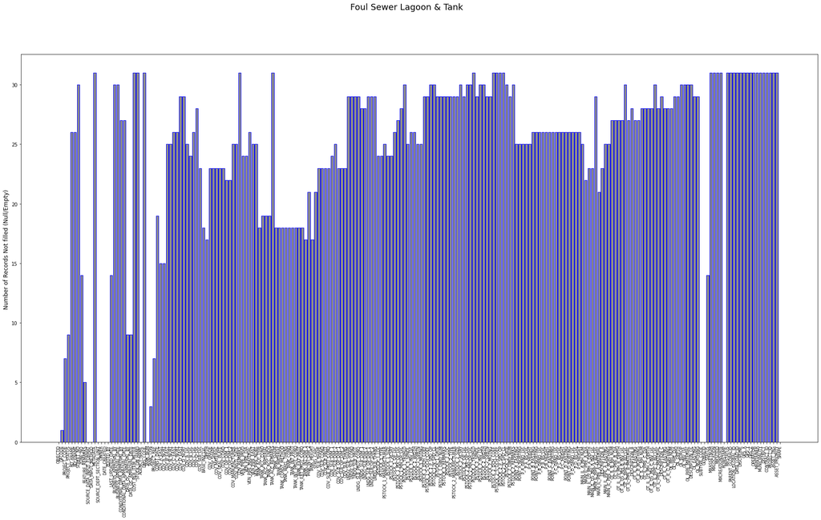

```python
x = FS_Lagoon_Tank.columns
y = FS_Lagoon_Tank.isnull().sum()
plt.figure(figsize=(30,15))
plt.bar(x, y, color= (0.1,0.1,0.1,0.5),  edgecolor='Blue')
plt.suptitle("Foul Sewer Lagoon & Tank", fontsize=18)
plt.ylabel("Number of Records Not filled (Null/Empty) ", fontsize=12)
plt.xticks(rotation=90, fontsize=8)
plt.show()
```

### 3. Foul Sewer Micro Tunnel Manhole - Polygon

Foul Sewer Micro Tunnel Manhole feature class has:

```
    •   Attribute Fields (Columns): 166
    •   Total Records (Rows): 859
```

```python
FS_Micro_Tunnel_Manhole = pd.DataFrame.spatial.from_featureclass(r"C:\Users\esd_kgathogo\AppData\Roaming\ESRI\Desktop10.7\ArcCatalog\PWAROADS.sde\SDE.DRG_FOUL_SEWER_NETWORK\SDE.SWARMTMH")
FS_Micro_Tunnel_Manhole.head(2)
```

|  | OBJECTID | GFCODE | PROJECT_CODE | PROJECT_STATUS | RD_ANAME | RD_ENAME | STREET_NO | ZONE_NO | FEATURE_REMARKS | SOURCE_DATA_INPUT_FORMAT | DATA_INPUT_METHOD | METADATA | SOURCE_DEPT_SECTION_UNIT | OWNER | DATE_CREATED | EDITED_BY | LAST_UPDATED_DATE | BUSINESS_APPROVAL_BY | BUSINESS_APPROVAL_DATE | CONDITIONAL_DATA_APPROVAL_BY | CONDITIONAL_DATA_APPROVAL_DATE | DATA_QC_APPROVAL_BY | DATA_QC_APPROVAL_DATE | COST_PER_ITEM_METER | STOCK_ON_HAND | AGENCY_NAME | DMS_CODE | ARMTMH_KY | SH_MH_NO | … |
| --- | --- | --- | --- | --- | --- | --- | --- | --- | --- | --- | --- | --- | --- | --- | --- | --- | --- | --- | --- | --- | --- | --- | --- | --- | --- | --- | --- | --- | --- | --- |
| 0 | 27924 | SWARMTMH | IA/13-14/C/021/G | As Built | None | None | NaN | NaN | None | Excel | Automation | None | Drainage O&M | O&M Drainage | 2019-02-14 13:04:54 | EA/VV | 2021-09-16 | None | None | None | NaT | EA/BD | 2021-09-19 | None | None | Ashghal | None | None | 16N/9 | … |
| 1 | 27925 | SWARMTMH | IA/13-14/C/021/G | As Built | None | None | NaN | NaN | None | Excel | Automation | None | Drainage O&M | O&M Drainage | 2019-02-14 13:04:54 | EA/VV | 2021-09-16 | None | None | None | NaT | EA/BD | 2021-09-19 | None | None | Ashghal | None | None | 16N/10 | … |

2 rows × 166 columns

```python
FS_Micro_Tunnel_Manhole.shape
```

```
(1171, 166)
```

```python
FS_Micro_Tunnel_Manhole_null = pd.DataFrame(FS_Micro_Tunnel_Manhole.isnull().sum())
FS_Micro_Tunnel_Manhole_null
```

|  | 0 |
| --- | --- |
| OBJECTID | 0 |
| GFCODE | 0 |
| PROJECT_CODE | 3 |
| PROJECT_STATUS | 3 |
| RD_ANAME | 1024 |
| ... | ... |
| CONTRACT_ID | 1171 |
| PROJECT_ID | 1112 |
| ASSET_TAG | 1112 |
| ASSET_PRIORITY | 1171 |
| SHAPE | 0 |

166 rows × 1 columns

[figure not shown]

```python
x = FS_Area_Engineer_Boundary.columns
y = FS_Area_Engineer_Boundary.isnull().sum()
plt.figure(figsize=(30,15))
plt.bar(x, y, color= (0.1,0.1,0.1,0.5),  edgecolor='Blue')
plt.suptitle("Foul Sewer Micro Tunnel Manhole", fontsize=18)
plt.ylabel("Number of Records Not filled (Null/Empty) ", fontsize=12)
plt.xticks(rotation=90, fontsize=12)
plt.show()
```

Foul Sewer Pumping Station Catchment Boundary feature class has:

```
    •   Attribute Fields (Columns): 71
    •   Total Records (Rows): 3,809
```

```python
FS_Pumping_Station_Catchment_Bounda = pd.DataFrame.spatial.from_featureclass(r"C:\Users\esd_kgathogo\AppData\Roaming\ESRI\Desktop10.7\ArcCatalog\PWAROADS.sde\SDE.DRG_SURFACE_GROUND_WATER_NETWORK\SDE.SGARDITH")
FS_Pumping_Station_Catchment_Bounda.head(2)
```

|  | OBJECTID | GFCODE | PROJECT_CODE | PROJECT_STATUS | RD_ANAME | RD_ENAME | STREET_NO | ZONE_NO | SOURCE_DATA_INPUT_FORMAT | DATA_INPUT_METHOD | METADATA | SOURCE_DEPT_SECTION_UNIT | OWNER | DATE_CREATED | EDITED_BY | LAST_UPDATED_DATE | BUSINESS_APPROVAL_BY | BUSINESS_APPROVAL_DATE | CONDITIONAL_DATA_APPROVAL_BY | CONDITIONAL_DATA_APPROVAL_DATE | DATA_QC_APPROVAL_BY | DATA_QC_APPROVAL_DATE | COST_PER_ITEM_METER | STOCK_ON_HAND | AGENCY_NAME | DMS_CODE | STATUS | SUBTYPE_CODE | MXASSETNUM | … |
| --- | --- | --- | --- | --- | --- | --- | --- | --- | --- | --- | --- | --- | --- | --- | --- | --- | --- | --- | --- | --- | --- | --- | --- | --- | --- | --- | --- | --- | --- | --- |
| 0 | 8 | Ditch | IA 12/13 C 063 ST | As Built | None | None | NaN | NaN | Excel | Automation | None | Drainage O&M | O&M Drainage | 2020-03-09 13:47:15 | ES/VV | 2020-04-13 | None | None | None | None | ES/BD | 2020-06-17 | None | None | Ashghal | None | CN | 1 | None | … |
| 1 | 9 | Ditch | IA 12/13 C 063 ST | As Built | None | None | NaN | NaN | Excel | Automation | None | Drainage O&M | O&M Drainage | 2020-03-09 13:47:15 | ES/VV | 2020-04-13 | None | None | None | None | ES/BD | 2020-06-17 | None | None | Ashghal | None | CN | 1 | None | … |

```python
FS_Pumping_Station_Catchment_Bounda.shape
```

```
(3809, 71)
```

```python
FS_Pumping_Station_Catchment_Bounda_null = pd.DataFrame(FS_Pumping_Station_Catchment_Bounda.isnull().sum())
FS_Pumping_Station_Catchment_Bounda_null
```

|  | 0 |
| --- | --- |
| OBJECTID | 0 |
| GFCODE | 0 |
| PROJECT_CODE | 695 |
| PROJECT_STATUS | 695 |
| RD_ANAME | 3685 |
| ... | ... |
| TAKAMUL_CATCHMENT | 6 |
| CONFIDENCE | 0 |
| RELIABLE | 783 |
| GLOBALID | 0 |
| SHAPE | 0 |

71 rows × 1 columns

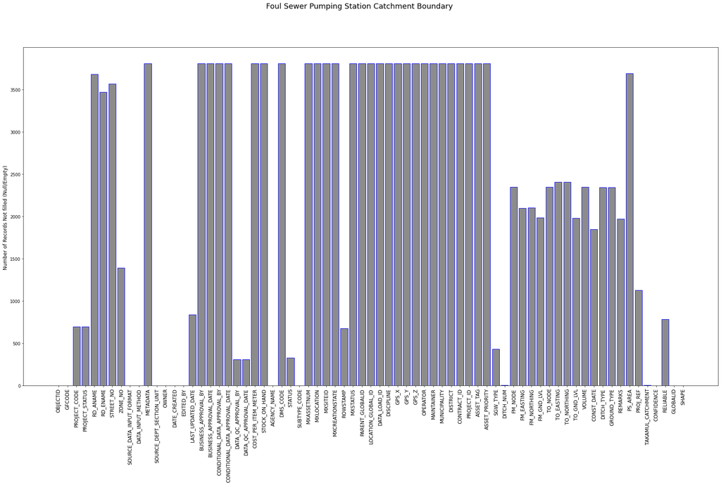

```python
x = FS_Pumping_Station_Catchment_Bounda.columns
y = FS_Pumping_Station_Catchment_Bounda.isnull().sum()
plt.figure(figsize=(30,15))
plt.bar(x, y, color= (0.1,0.1,0.1,0.5),  edgecolor='Blue')
plt.suptitle("Foul Sewer Pumping Station Catchment Boundary", fontsize=18)
plt.ylabel("Number of Records Not filled (Null/Empty) ", fontsize=12)
plt.xticks(rotation=90, fontsize=12)
plt.show()
```

### 5. Foul Sewer Takamul Supply Zone Catchment Boundries

Foul Sewer Takamul Supply Zone Catchment Boundries feature class has:

```
    •   Attribute Fields (Columns): 6
    •   Total Records (Rows): 4
```

```python
FS_Takamul_Supply_Zone_Catchment_Boundries = pd.DataFrame.spatial.from_featureclass(r"C:\Users\esd_kgathogo\AppData\Roaming\ESRI\Desktop10.7\ArcCatalog\PWAROADS.sde\SDE.DRG_FOUL_SEWER_NETWORK\SDE.SWARSZCB")
FS_Takamul_Supply_Zone_Catchment_Boundries.head(2)
```

|  | OBJECTID | CATCHMENT | CONTRACTOR_ID | CONTRACTOR | GLOBALID | SHAPE |
| --- | --- | --- | --- | --- | --- | --- |
| 0 | 647 | Qatar West | C/2020/50 | AGUAS DE VALENCIA - MACE QATAR JV | {C122CA1F-4F56-4578-BCFF-BF70D0DFB91A} | {"rings": [[[179828.14300000016, 408500.840099... |
| 1 | 646 | Qatar South | C/2020/28 | METITO (OVERSEAS) QATAR | {34935778-535B-4AED-8502-FF956F455674} | {"rings": [[[237670.892, 392467.02339999937], ... |

```python
FS_Takamul_Supply_Zone_Catchment_Boundries.shape
```

```
(4, 6)
```

```python
FS_Takamul_Supply_Zone_Catchment_Boundries_null = pd.DataFrame(FS_Takamul_Supply_Zone_Catchment_Boundries.isnull().sum())
FS_Takamul_Supply_Zone_Catchment_Boundries_null
```

|  | 0 |
| --- | --- |
| OBJECTID | 0 |
| CATCHMENT | 0 |
| CONTRACTOR_ID | 1 |
| CONTRACTOR | 1 |
| GLOBALID | 0 |
| SHAPE | 0 |

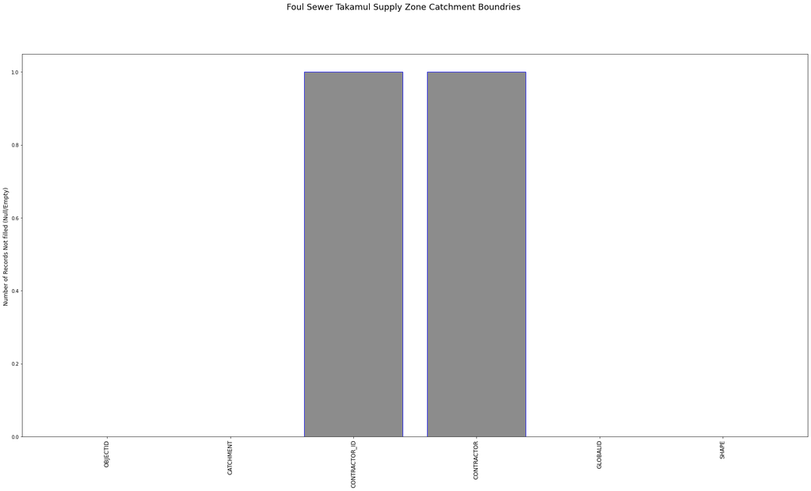

```python
x = FS_Takamul_Supply_Zone_Catchment_Boundries.columns
y = FS_Takamul_Supply_Zone_Catchment_Boundries.isnull().sum()
plt.figure(figsize=(30,15))
plt.bar(x, y, color= (0.1,0.1,0.1,0.5),  edgecolor='Blue')
plt.suptitle(" Foul Sewer Takamul Supply Zone Catchment Boundries", fontsize=18)
plt.ylabel("Number of Records Not filled (Null/Empty) ", fontsize=12)
plt.xticks(rotation=90, fontsize=12)
plt.show()
```

### 6. Foul Sewer Valve Chamber

Foul Sewer Valve Chamber feature class has:

```
    •   Attribute Fields (Columns): 106
    •   Total Records (Rows): 768
```

```python
FS_Valve_Chamber = pd.DataFrame.spatial.from_featureclass(r"C:\Users\esd_kgathogo\AppData\Roaming\ESRI\Desktop10.7\ArcCatalog\PWAROADS.sde\SDE.DRG_FOUL_SEWER_NETWORK\SDE.SWARVLCH")
FS_Valve_Chamber.head(2)
```

|  | OBJECTID | GFCODE | PROJECT_CODE | PROJECT_STATUS | RD_ANAME | RD_ENAME | STREET_NO | ZONE_NO | FEATURE_REMARKS | SOURCE_DATA_INPUT_FORMAT | DATA_INPUT_METHOD | METADATA | SOURCE_DEPT_SECTION_UNIT | OWNER | DATE_CREATED | EDITED_BY | LAST_UPDATED_DATE | BUSINESS_APPROVAL_BY | BUSINESS_APPROVAL_DATE | CONDITIONAL_DATA_APPROVAL_BY | CONDITIONAL_DATA_APPROVAL_DATE | DATA_QC_APPROVAL_BY | DATA_QC_APPROVAL_DATE | COST_PER_ITEM_METER | STOCK_ON_HAND | AGENCY_NAME | DMS_CODE | ARVLCH_KY | PROJECT_REF | … |
| --- | --- | --- | --- | --- | --- | --- | --- | --- | --- | --- | --- | --- | --- | --- | --- | --- | --- | --- | --- | --- | --- | --- | --- | --- | --- | --- | --- | --- | --- | --- |
| 0 | 29345 | SWARVLCH | IA 10/11 C 117 G | As Built Yet to be Approved | None | None | NaN | 66.0 | None | Excel | Automation | None | Drainage O&M | O&M Drainage | 2021-05-27 | VB | 2021-08-09 | None | NaT | None | NaT | ES | 2021-08-09 | None | None | Ashghal | None | NaN | C2012/18 | … |
| 1 | 29342 | SWARVLCH | None | None | None | None | NaN | NaN | Four Corners captured for beneficiary purpose.... | None | None | None | None | None | NaT | None | NaT | None | NaT | None | NaT | None | NaT | None | None | Ashghal | None | NaN | C2005/1 | … |

2 rows × 106 columns

```python
FS_Valve_Chamber.shape
```

```
(838, 106)
```

```python
FS_Valve_Chamber_null = pd.DataFrame(FS_Valve_Chamber.isnull().sum())
FS_Valve_Chamber_null
```

|  | 0 |
| --- | --- |
| OBJECTID | 0 |
| GFCODE | 0 |
| PROJECT_CODE | 11 |
| PROJECT_STATUS | 233 |
| RD_ANAME | 755 |
| ... | ... |
| CONTRACT_ID | 838 |
| PROJECT_ID | 838 |
| ASSET_TAG | 837 |
| ASSET_PRIORITY | 838 |
| SHAPE | 0 |

106 rows × 1 columns

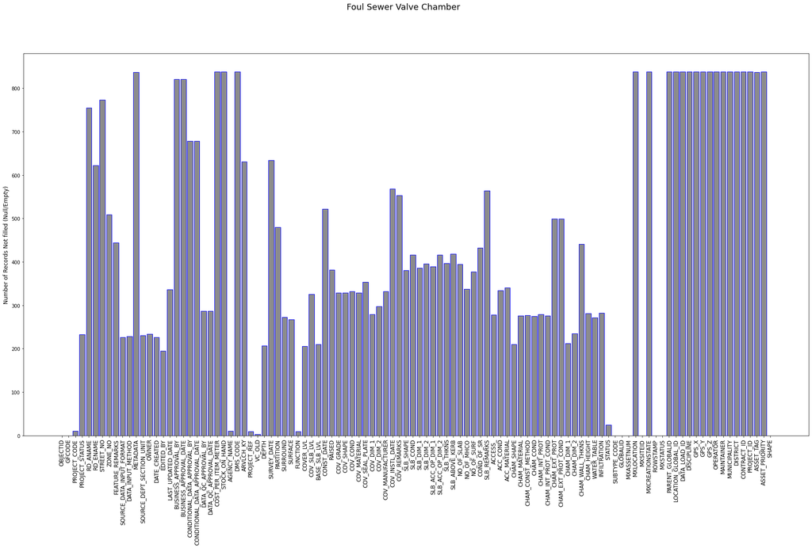

```python
x = FS_Valve_Chamber.columns
y = FS_Valve_Chamber.isnull().sum()
plt.figure(figsize=(30,15))
plt.bar(x, y, color= (0.1,0.1,0.1,0.5),  edgecolor='Blue')
plt.suptitle("Foul Sewer Valve Chamber", fontsize=18)
plt.ylabel("Number of Records Not filled (Null/Empty)", fontsize=12)
plt.xticks(rotation=90, fontsize=12)
plt.show()
```

### 7. Foul Sewer House Connection

Foul Sewer House Connection feature class has:

```
    •   Attribute Fields (Columns): 70
    •   Total Records (Rows): 75,989
```

```python
FS_House_Connection = pd.DataFrame.spatial.from_featureclass(r"C:\Users\esd_kgathogo\AppData\Roaming\ESRI\Desktop10.7\ArcCatalog\PWAROADS.sde\SDE.DRG_FOUL_SEWER_NETWORK\SDE.SWLNHCON")
FS_House_Connection.head(2)
```

|  | OBJECTID | GFCODE | PROJECT_CODE | PROJECT_STATUS | RD_ANAME | RD_ENAME | STREET_NO | ZONE_NO | FEATURE_REMARKS | SOURCE_DATA_INPUT_FORMAT | DATA_INPUT_METHOD | METADATA | SOURCE_DEPT_SECTION_UNIT | OWNER | DATE_CREATED | EDITED_BY | LAST_UPDATED_DATE | BUSINESS_APPROVAL_BY | BUSINESS_APPROVAL_DATE | CONDITIONAL_DATA_APPROVAL_BY | CONDITIONAL_DATA_APPROVAL_DATE | DATA_QC_APPROVAL_BY | DATA_QC_APPROVAL_DATE | COST_PER_ITEM_METER | STOCK_ON_HAND | AGENCY_NAME | DMS_CODE | PROJECT_REF | HC_NUM | … |
| --- | --- | --- | --- | --- | --- | --- | --- | --- | --- | --- | --- | --- | --- | --- | --- | --- | --- | --- | --- | --- | --- | --- | --- | --- | --- | --- | --- | --- | --- | --- |
| 0 | 2896370 | SWLNHCON |  | None | None | HATEM AL TAEI | 990.0 | 37.0 |  | None | None | None | None | None | NaT | None | NaT | None | NaT | None | NaT | None | NaT | NaN | NaN | None | None |  | 951CN4 | … |
| 1 | 2894081 | SWLNHCON | 37852-NLH-NPD-LIP | As Built | None | None | NaN | 69.0 | None | Excel | Manual | None | Drainage O&M | O&M Drainage | 2017-12-25 07:52:06 | ES | 2018-01-31 12:29:05 | None | NaT | None | NaT | ES/AH(FQC) | 2018-01-31 12:30:58 | NaN | NaN | Ashghal | None | CP05A & CP06A | HCF/NRV/A031 | … |

```python
FS_House_Connection.shape
```

```
(77555, 70)
```

```python
FS_House_Connection_null = pd.DataFrame(FS_House_Connection.isnull().sum())
FS_House_Connection_null
```

|  | 0 |
| --- | --- |
| OBJECTID | 0 |
| GFCODE | 0 |
| PROJECT_CODE | 10028 |
| PROJECT_STATUS | 51519 |
| RD_ANAME | 75061 |
| ... | ... |
| CONTRACT_ID | 77095 |
| PROJECT_ID | 77555 |
| ASSET_TAG | 77555 |
| ASSET_PRIORITY | 77555 |
| SHAPE | 0 |

70 rows × 1 columns

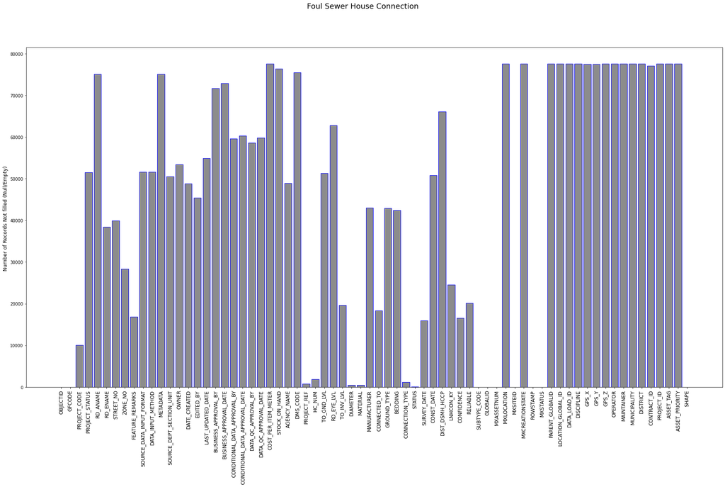

```python
x = FS_House_Connection.columns
y = FS_House_Connection.isnull().sum()
plt.figure(figsize=(30,15))
plt.bar(x, y, color= (0.1,0.1,0.1,0.5),  edgecolor='Blue')
plt.suptitle("Foul Sewer House Connection", fontsize=18)
plt.ylabel("Number of Records Not filled (Null/Empty) ", fontsize=12)
plt.xticks(rotation=90, fontsize=12)
plt.show()
```

### 8. Foul Sewer House Connection Stub Pipe

Foul Sewer House Connection Stub Pipe feature class has:

```
    •   Attribute Fields (Columns): 70
    •   Total Records (Rows): 35,190
```

```python
FS_House_Connection_Stub_Pipe = pd.DataFrame.spatial.from_featureclass(r"C:\Users\esd_kgathogo\AppData\Roaming\ESRI\Desktop10.7\ArcCatalog\PWAROADS.sde\SDE.DRG_FOUL_SEWER_NETWORK\SDE.SWLNHCST")
FS_House_Connection_Stub_Pipe.head(2)
```

|  | OBJECTID | GFCODE | PROJECT_CODE | PROJECT_STATUS | RD_ANAME | RD_ENAME | STREET_NO | ZONE_NO | FEATURE_REMARKS | SOURCE_DATA_INPUT_FORMAT | DATA_INPUT_METHOD | METADATA | SOURCE_DEPT_SECTION_UNIT | OWNER | DATE_CREATED | EDITED_BY | LAST_UPDATED_DATE | BUSINESS_APPROVAL_BY | BUSINESS_APPROVAL_DATE | CONDITIONAL_DATA_APPROVAL_BY | CONDITIONAL_DATA_APPROVAL_DATE | DATA_QC_APPROVAL_BY | DATA_QC_APPROVAL_DATE | COST_PER_ITEM_METER | STOCK_ON_HAND | AGENCY_NAME | DMS_CODE | LNHCST_KY | PROJECT_REF | … |
| --- | --- | --- | --- | --- | --- | --- | --- | --- | --- | --- | --- | --- | --- | --- | --- | --- | --- | --- | --- | --- | --- | --- | --- | --- | --- | --- | --- | --- | --- | --- |
| 0 | 1213056 | SWLNHCST | AA/DOM/13-14M/1591-4.07G | As Built | None | None | NaN | NaN | None | Excel | Automation | None | Drainage O&M | O&M Drainage | 2021-04-04 | BH | 2021-04-28 | None | NaT | None | NaT | ES | 2021-04-28 | NaN | NaN | Ashghal | None | NaN | C2019/67 | … |
| 1 | 1212921 | SWLNHCST | IA 15/16 C010 G | As Built Yet to be Approved | None | None | NaN | NaN | Stubpipe details was captured from the drawing... | DWG | Digitization | None | Drainage O&M | O&M Drainage | 2021-12-05 | BD | NaT | None | NaT | None | NaT | BD | 2021-12-08 | NaN | NaN | Ashghal | None | NaN | C2016/16 | … |

```python
FS_House_Connection_Stub_Pipe.shape
```

```
(38832, 70)
```

```python
FS_House_Connection_Stub_Pipe_null = pd.DataFrame(FS_House_Connection_Stub_Pipe.isnull().sum())
FS_House_Connection_Stub_Pipe_null
```

|  | 0 |
| --- | --- |
| OBJECTID | 0 |
| GFCODE | 0 |
| PROJECT_CODE | 22 |
| PROJECT_STATUS | 15413 |
| RD_ANAME | 36013 |
| ... | ... |
| CONTRACT_ID | 38796 |
| PROJECT_ID | 38832 |
| ASSET_TAG | 38832 |
| ASSET_PRIORITY | 38832 |
| SHAPE | 0 |

70 rows × 1 columns

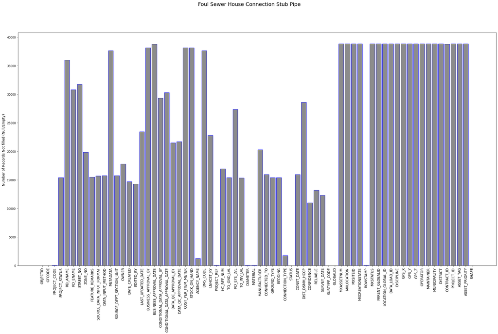

```python
x = FS_House_Connection_Stub_Pipe.columns
y = FS_House_Connection_Stub_Pipe.isnull().sum()
plt.figure(figsize=(30,15))
plt.bar(x, y, color= (0.1,0.1,0.1,0.5),  edgecolor='Blue')
plt.suptitle("Foul Sewer House Connection Stub Pipe", fontsize=18)
plt.ylabel("Number of Records Not filled (Null/Empty) ", fontsize=12)
plt.xticks(rotation=90, fontsize=12)
plt.show()
```

### 9. Foul Sewer Micro Tunnel Sewer Pipe

Foul Sewer Micro Tunnel Sewer Pipe feature class has:

```
    •   Attribute Fields (Columns): 91
    •   Total Records (Rows): 3,240
```

```python
FS_Sewer_MT_Sewer_Pipe = pd.DataFrame.spatial.from_featureclass(r"C:\Users\esd_kgathogo\AppData\Roaming\ESRI\Desktop10.7\ArcCatalog\PWAROADS.sde\SDE.DRG_FOUL_SEWER_NETWORK\SDE.SWLNMTSW")
FS_Sewer_MT_Sewer_Pipe.head(2)
```

|  | OBJECTID | GFCODE | PROJECT_CODE | PROJECT_STATUS | RD_ANAME | RD_ENAME | STREET_NO | ZONE_NO | FEATURE_REMARKS | SOURCE_DATA_INPUT_FORMAT | DATA_INPUT_METHOD | METADATA | SOURCE_DEPT_SECTION_UNIT | OWNER | DATE_CREATED | EDITED_BY | LAST_UPDATED_DATE | BUSINESS_APPROVAL_BY | BUSINESS_APPROVAL_DATE | CONDITIONAL_DATA_APPROVAL_BY | CONDITIONAL_DATA_APPROVAL_DATE | DATA_QC_APPROVAL_BY | DATA_QC_APPROVAL_DATE | COST_PER_ITEM_METER | STOCK_ON_HAND | AGENCY_NAME | DMS_CODE | PROJECT_REF | PIPE_TYPE | … |
| --- | --- | --- | --- | --- | --- | --- | --- | --- | --- | --- | --- | --- | --- | --- | --- | --- | --- | --- | --- | --- | --- | --- | --- | --- | --- | --- | --- | --- | --- | --- |
| 0 | 100728 | SWLNMTSW | IA13/14 C42 M | As Built Yet to be Approved | المعاضيد | Al Maadeed | 980.0 | 55.0 | None | DWG | Manual | None | Drainage O&M | O&M Drainage | 2019-05-06 08:53:53.000000 | ES | 2019-05-06 08:53:54 | None | NaT | None | NaT | ES | 2019-05-06 08:53:55.000000 | None | None | Ashghal | None | C2015/69 | Standard | … |
| 1 | 100439 | SWLNMTSW | IA 13/14 C 06 ST | As Built | None | None | NaN | 53.0 | None | Excel | Automation | None | Drainage O&M | O&M Drainage | 2018-10-24 11:20:59.000001 | EA | NaT | None | NaT | None | NaT | EA | 2018-10-23 08:38:41.000001 | None | None | Ashghal | None | C2013/104 | Standard | … |

2 rows × 91 columns

```python
FS_Sewer_MT_Sewer_Pipe.shape
```

```
(3552, 91)
```

```python
FS_Sewer_MT_Sewer_Pipe_null = pd.DataFrame(FS_Sewer_MT_Sewer_Pipe.isnull().sum())
```

```python
FS_Sewer_MT_Sewer_Pipe.head(2)
```

|  | OBJECTID | GFCODE | PROJECT_CODE | PROJECT_STATUS | RD_ANAME | RD_ENAME | STREET_NO | ZONE_NO | FEATURE_REMARKS | SOURCE_DATA_INPUT_FORMAT | DATA_INPUT_METHOD | METADATA | SOURCE_DEPT_SECTION_UNIT | OWNER | DATE_CREATED | EDITED_BY | LAST_UPDATED_DATE | BUSINESS_APPROVAL_BY | BUSINESS_APPROVAL_DATE | CONDITIONAL_DATA_APPROVAL_BY | CONDITIONAL_DATA_APPROVAL_DATE | DATA_QC_APPROVAL_BY | DATA_QC_APPROVAL_DATE | COST_PER_ITEM_METER | STOCK_ON_HAND | AGENCY_NAME | DMS_CODE | PROJECT_REF | PIPE_TYPE | … |
| --- | --- | --- | --- | --- | --- | --- | --- | --- | --- | --- | --- | --- | --- | --- | --- | --- | --- | --- | --- | --- | --- | --- | --- | --- | --- | --- | --- | --- | --- | --- |
| 0 | 100728 | SWLNMTSW | IA13/14 C42 M | As Built Yet to be Approved | المعاضيد | Al Maadeed | 980.0 | 55.0 | None | DWG | Manual | None | Drainage O&M | O&M Drainage | 2019-05-06 08:53:53.000000 | ES | 2019-05-06 08:53:54 | None | NaT | None | NaT | ES | 2019-05-06 08:53:55.000000 | None | None | Ashghal | None | C2015/69 | Standard | … |
| 1 | 100439 | SWLNMTSW | IA 13/14 C 06 ST | As Built | None | None | NaN | 53.0 | None | Excel | Automation | None | Drainage O&M | O&M Drainage | 2018-10-24 11:20:59.000001 | EA | NaT | None | NaT | None | NaT | EA | 2018-10-23 08:38:41.000001 | None | None | Ashghal | None | C2013/104 | Standard | … |

2 rows × 91 columns

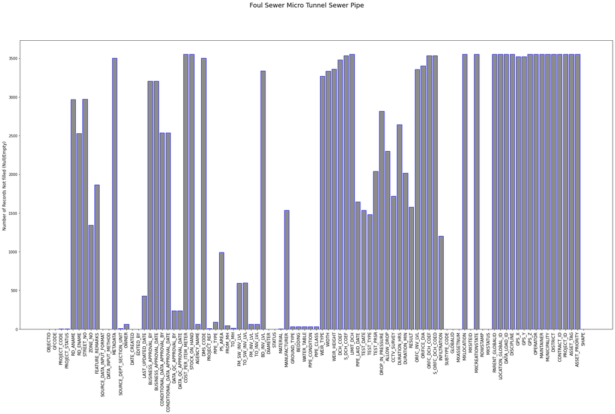

```python
x = FS_Sewer_MT_Sewer_Pipe.columns
y = FS_Sewer_MT_Sewer_Pipe.isnull().sum()
plt.figure(figsize=(30,15))
plt.bar(x, y, color= (0.1,0.1,0.1,0.5),  edgecolor='Blue')
plt.suptitle("Foul Sewer Micro Tunnel Sewer Pipe", fontsize=18)
plt.ylabel("Number of Records Not filled (Null/Empty) ", fontsize=12)
plt.xticks(rotation=90, fontsize=12)
plt.show()
```

### 10. Foul Sewer Rising Main

Foul Sewer Rising Main feature class has:

```
    •   Attribute Fields (Columns): 86
    •   Total Records (Rows): 9,742
```

```python
FS_Rising_Main = pd.DataFrame.spatial.from_featureclass(r"C:\Users\esd_kgathogo\AppData\Roaming\ESRI\Desktop10.7\ArcCatalog\PWAROADS.sde\SDE.DRG_FOUL_SEWER_NETWORK\SDE.SWLNRSMN")
FS_Rising_Main.head(2)
```

|  | OBJECTID | GFCODE | PROJECT_CODE | PROJECT_STATUS | RD_ANAME | RD_ENAME | STREET_NO | ZONE_NO | FEATURE_REMARKS | SOURCE_DATA_INPUT_FORMAT | DATA_INPUT_METHOD | METADATA | SOURCE_DEPT_SECTION_UNIT | OWNER | DATE_CREATED | EDITED_BY | LAST_UPDATED_DATE | BUSINESS_APPROVAL_BY | BUSINESS_APPROVAL_DATE | CONDITIONAL_DATA_APPROVAL_BY | CONDITIONAL_DATA_APPROVAL_DATE | DATA_QC_APPROVAL_BY | DATA_QC_APPROVAL_DATE | COST_PER_ITEM_METER | STOCK_ON_HAND | AGENCY_NAME | DMS_CODE | PROJECT_REF | PS_AREA | … |
| --- | --- | --- | --- | --- | --- | --- | --- | --- | --- | --- | --- | --- | --- | --- | --- | --- | --- | --- | --- | --- | --- | --- | --- | --- | --- | --- | --- | --- | --- | --- |
| 0 | 293041 | SWLNRSMN | IA-D/13-14/DCOM/03/G | As Built Yet to be Approved | None | None | NaN | NaN | None | As Built | Automation | None | Drainage O&M | O&M Drainage | 2019-12-14 | VV | NaT | None | NaT | None | NaT | VV/EA | 2019-12-14 | NaN | NaN | Ashghal | None | C2014/140 | None | … |
| 1 | 293636 | SWLNRSMN | IA-D/13-14/DCOM/03/G | As Built Yet to be Approved | None | None | NaN | NaN | None | As Built | Automation | None | Drainage O&M | O&M Drainage | 2019-12-14 | VV | NaT | None | NaT | None | NaT | VV/EA | 2019-12-14 | NaN | NaN | Ashghal | None | C2014/140 | None | … |

2 rows × 86 columns

```python
FS_Rising_Main.shape
```

```
(10672, 86)
```

```python
FS_Rising_Main_null = pd.DataFrame(FS_Rising_Main.isnull().sum())
```

```python
FS_Rising_Main_null
```

|  | 0 |
| --- | --- |
| OBJECTID | 0 |
| GFCODE | 0 |
| PROJECT_CODE | 35 |
| PROJECT_STATUS | 3746 |
| RD_ANAME | 10372 |
| ... | ... |
| CONTRACT_ID | 10672 |
| PROJECT_ID | 10672 |
| ASSET_TAG | 10672 |
| ASSET_PRIORITY | 10672 |
| SHAPE | 0 |

86 rows × 1 columns

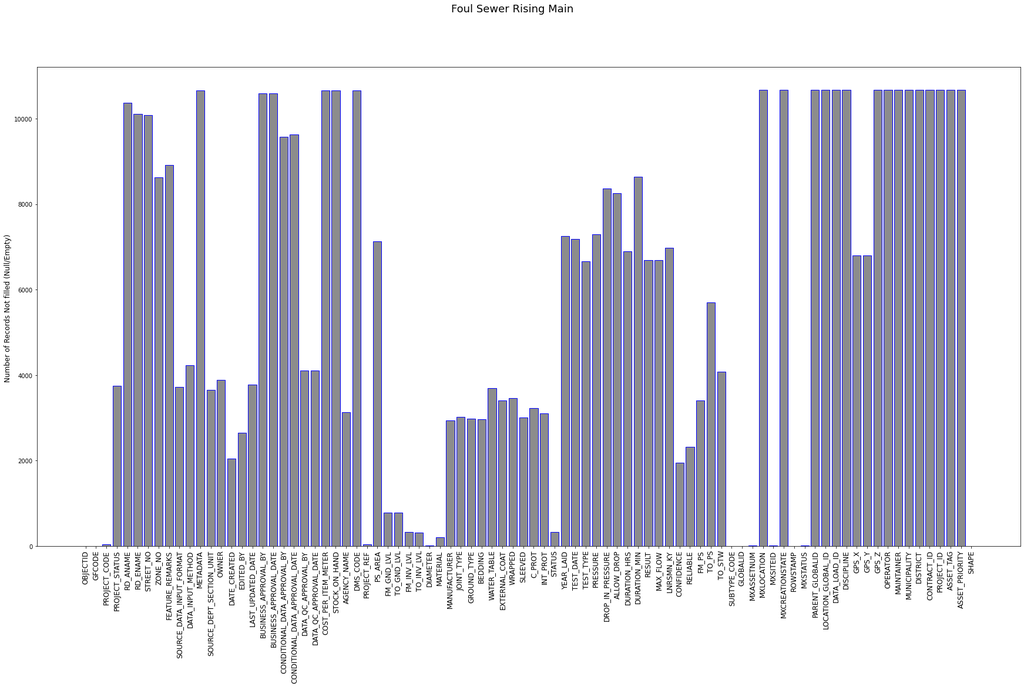

```python
x = FS_Rising_Main.columns
y = FS_Rising_Main.isnull().sum()
plt.figure(figsize=(30,15))
plt.bar(x, y, color= (0.1,0.1,0.1,0.5),  edgecolor='Blue')
plt.suptitle("Foul Sewer Rising Main", fontsize=18)
plt.ylabel("Number of Records Not filled (Null/Empty) ", fontsize=12)
plt.xticks(rotation=90, fontsize=12)
plt.show()
```

### 12. Foul Sewer Pipe

Foul Sewer Pipe feature class has:

```
    •   Attribute Fields (Columns): 92
    •   Total Records (Rows): 82,133
```

```python
FS_Pipe = pd.DataFrame.spatial.from_featureclass(r"C:\Users\esd_kgathogo\AppData\Roaming\ESRI\Desktop10.7\ArcCatalog\PWAROADS.sde\SDE.DRG_FOUL_SEWER_NETWORK\SDE.SWLNSEWR")
FS_Pipe.head(2)
```

|  | OBJECTID | GFCODE | PROJECT_CODE | PROJECT_STATUS | RD_ANAME | RD_ENAME | STREET_NO | ZONE_NO | FEATURE_REMARKS | SOURCE_DATA_INPUT_FORMAT | DATA_INPUT_METHOD | METADATA | SOURCE_DEPT_SECTION_UNIT | OWNER | DATE_CREATED | EDITED_BY | LAST_UPDATED_DATE | BUSINESS_APPROVAL_BY | BUSINESS_APPROVAL_DATE | CONDITIONAL_DATA_APPROVAL_BY | CONDITIONAL_DATA_APPROVAL_DATE | DATA_QC_APPROVAL_BY | DATA_QC_APPROVAL_DATE | COST_PER_ITEM_METER | STOCK_ON_HAND | AGENCY_NAME | DMS_CODE | PROJECT_REF | PIPE_TYPE | … |
| --- | --- | --- | --- | --- | --- | --- | --- | --- | --- | --- | --- | --- | --- | --- | --- | --- | --- | --- | --- | --- | --- | --- | --- | --- | --- | --- | --- | --- | --- | --- |
| 0 | 2954161 | SWLNSEWR | IA 14 15 C 008 ST | As Built | None | None | NaN | 50.0 | None | Excel | Manual | None | Drainage O&M | O&M Drainage | 2018-09-04 09:32:07 | ES/IW | 2019-05-22 13:19:00 | None | NaT | None | NaT | ES/EA | 2019-05-22 13:22:49 | NaN | NaN | Ashghal | None | C2015/46 | 1 | … |
| 1 | 2953995 | SWLNSEWR | IA 12/13 C 071 ST | As Built | None | None | NaN | NaN | - | Excel | Automation | None | Drainage O&M | O&M Drainage | 2018-05-23 00:00:00 | EA/BH | 2019-03-06 00:00:00 | None | NaT | None | NaT | EA/BH | 2019-03-06 00:00:00 | NaN | NaN | Ashghal | None | C2014/127 | Standard | … |

2 rows × 92 columns

```python
FS_Pipe.shape
```

```
(85980, 92)
```

```python
FS_Pipe_null = pd.DataFrame(FS_Pipe.isnull().sum())
```

```python
FS_Pipe_null
```

|  | 0 |
| --- | --- |
| OBJECTID | 0 |
| GFCODE | 0 |
| PROJECT_CODE | 1547 |
| PROJECT_STATUS | 50766 |
| RD_ANAME | 81545 |
| ... | ... |
| CONTRACT_ID | 85909 |
| PROJECT_ID | 85980 |
| ASSET_TAG | 85980 |
| ASSET_PRIORITY | 85980 |
| SHAPE | 0 |

92 rows × 1 columns

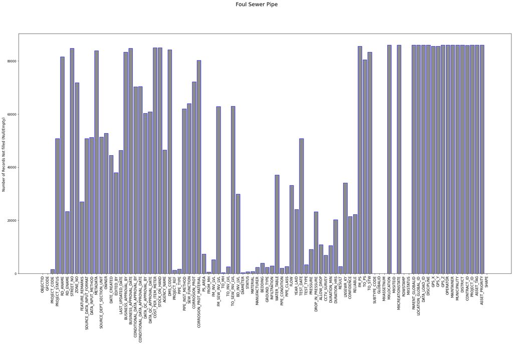

```python
x = FS_Pipe.columns
y = FS_Pipe.isnull().sum()
plt.figure(figsize=(30,15))
plt.bar(x, y, color= (0.1,0.1,0.1,0.5),  edgecolor='Blue')
plt.suptitle("Foul Sewer Pipe", fontsize=18)
plt.ylabel("Number of Records Not filled (Null/Empty) ", fontsize=12)
plt.xticks(rotation=90, fontsize=12)
plt.show()
```

### 12. Foul Sewer Stub Pipe

Foul Sewer Stub Pipe feature class has:

```
    •   Attribute Fields (Columns): 90
    •   Total Records (Rows): 431
```

```python
FS_Stub_Pipe = pd.DataFrame.spatial.from_featureclass(r"C:\Users\esd_kgathogo\AppData\Roaming\ESRI\Desktop10.7\ArcCatalog\PWAROADS.sde\SDE.DRG_FOUL_SEWER_NETWORK\SDE.SWLNSTUB")
FS_Stub_Pipe.head(2)
```

|  | OBJECTID | GFCODE | PROJECT_CODE | PROJECT_STATUS | RD_ANAME | RD_ENAME | STREET_NO | ZONE_NO | FEATURE_REMARKS | SOURCE_DATA_INPUT_FORMAT | DATA_INPUT_METHOD | METADATA | SOURCE_DEPT_SECTION_UNIT | OWNER | DATE_CREATED | EDITED_BY | LAST_UPDATED_DATE | BUSINESS_APPROVAL_BY | BUSINESS_APPROVAL_DATE | CONDITIONAL_DATA_APPROVAL_BY | CONDITIONAL_DATA_APPROVAL_DATE | DATA_QC_APPROVAL_BY | DATA_QC_APPROVAL_DATE | COST_PER_ITEM_METER | STOCK_ON_HAND | AGENCY_NAME | DMS_CODE | PROJECT_REF | PIPE_TYPE | … |
| --- | --- | --- | --- | --- | --- | --- | --- | --- | --- | --- | --- | --- | --- | --- | --- | --- | --- | --- | --- | --- | --- | --- | --- | --- | --- | --- | --- | --- | --- | --- |
| 0 | 19008 | SWLNSTUB | CP05B | As Built | None | None | NaN | 69.0 | CONNECTED-CP7C-1B | Excel | Manual | None | Drainage O&M | O&M Drainage | 2018-04-01 13:00:58 | ES | 2018-04-01 13:01:00 | None | None | None | NaT | ES/AH(FQC) | 2018-04-01 13:01:03 | None | None | Ashghal | None | 2888 | Standard | … |
| 1 | 19009 | SWLNSTUB | CP05B | As Built | None | None | NaN | 69.0 | None | Excel | Manual | None | Drainage O&M | O&M Drainage | 2018-04-01 13:00:58 | ES | 2018-04-01 13:01:00 | None | None | None | NaT | ES/AH(FQC) | 2018-04-01 13:01:03 | None | None | Ashghal | None | 2888 | Standard | … |

2 rows × 90 columns

```python
FS_Stub_Pipe.shape
```

```
(458, 90)
```

```python
FS_Stub_Pipe_null = pd.DataFrame(FS_Stub_Pipe.isnull().sum())
```

```python
FS_Stub_Pipe_null
```

|  | 0 |
| --- | --- |
| OBJECTID | 0 |
| GFCODE | 0 |
| PROJECT_CODE | 2 |
| PROJECT_STATUS | 21 |
| RD_ANAME | 378 |
| ... | ... |
| CONTRACT_ID | 458 |
| PROJECT_ID | 458 |
| ASSET_TAG | 458 |
| ASSET_PRIORITY | 458 |
| SHAPE | 0 |

90 rows × 1 columns

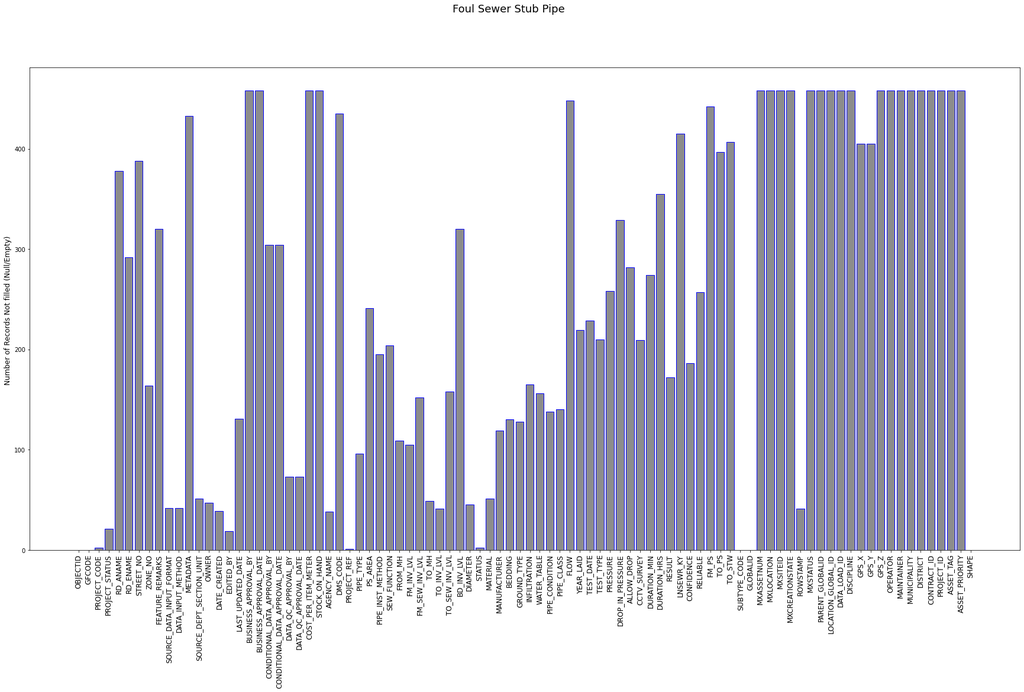

```python
x = FS_Stub_Pipe.columns
y = FS_Stub_Pipe.isnull().sum()
plt.figure(figsize=(30,15))
plt.bar(x, y, color= (0.1,0.1,0.1,0.5),  edgecolor='Blue')
plt.suptitle("Foul Sewer Stub Pipe", fontsize=18)
plt.ylabel("Number of Records Not filled (Null/Empty) ", fontsize=12)
plt.xticks(rotation=90, fontsize=12)
plt.show()
```

### 13. Foul Sewer Blockage Maintenance Chamber

Foul Sewer Blockage Maintenance Chamber feature class has:

```
    •   Attribute Fields (Columns): 115
    •   Total Records (Rows): 388
```

```python
FS_Blockage_Maintenance_Chamber = pd.DataFrame.spatial.from_featureclass(r"C:\Users\esd_kgathogo\AppData\Roaming\ESRI\Desktop10.7\ArcCatalog\PWAROADS.sde\SDE.DRG_FOUL_SEWER_NETWORK\SDE.SWNDBMCH")
FS_Blockage_Maintenance_Chamber.head(2)
```

|  | OBJECTID | GFCODE | PROJECT_CODE | PROJECT_STATUS | RD_ANAME | RD_ENAME | STREET_NO | ZONE_NO | FEATURE_REMARKS | SOURCE_DATA_INPUT_FORMAT | DATA_INPUT_METHOD | METADATA | SOURCE_DEPT_SECTION_UNIT | OWNER | DATE_CREATED | EDITED_BY | LAST_UPDATED_DATE | BUSINESS_APPROVAL_BY | BUSINESS_APPROVAL_DATE | CONDITIONAL_DATA_APPROVAL_BY | CONDITIONAL_DATA_APPROVAL_DATE | DATA_QC_APPROVAL_BY | DATA_QC_APPROVAL_DATE | COST_PER_ITEM_METER | STOCK_ON_HAND | AGENCY_NAME | DMS_CODE | NDBMCH_KY | BMCH_NUM | … |
| --- | --- | --- | --- | --- | --- | --- | --- | --- | --- | --- | --- | --- | --- | --- | --- | --- | --- | --- | --- | --- | --- | --- | --- | --- | --- | --- | --- | --- | --- | --- |
| 0 | 18188 | SWNDBMCH |  | None | None | None | NaN | NaN | None | None | None | None | None | None | NaT | None | NaT | None | None | None | NaT | None | NaT | None | None | None | None | 0.0 | 21/105/5/V1 | … |
| 1 | 18189 | SWNDBMCH | None | AS BUILT | None | None | NaN | NaN | None | R/S | MANUAL | None | O & M | None | 2013-10-24 12:08:22 | ERIC/LATIF | NaT | None | None | O & M | NaT | O & M | NaT | None | None | Ashghal | None | NaN | 5/E4/1/S1 | … |

2 rows × 115 columns

```python
FS_Blockage_Maintenance_Chamber.shape
```

```
(389, 115)
```

```python
FS_Blockage_Maintenance_Chamber_null = pd.DataFrame(FS_Blockage_Maintenance_Chamber.isnull().sum())
```

```python
FS_Blockage_Maintenance_Chamber_null
```

|  | 0 |
| --- | --- |
| OBJECTID | 0 |
| GFCODE | 0 |
| PROJECT_CODE | 7 |
| PROJECT_STATUS | 126 |
| RD_ANAME | 243 |
| ... | ... |
| CONTRACT_ID | 389 |
| PROJECT_ID | 389 |
| ASSET_TAG | 389 |
| ASSET_PRIORITY | 389 |
| SHAPE | 0 |

115 rows × 1 columns

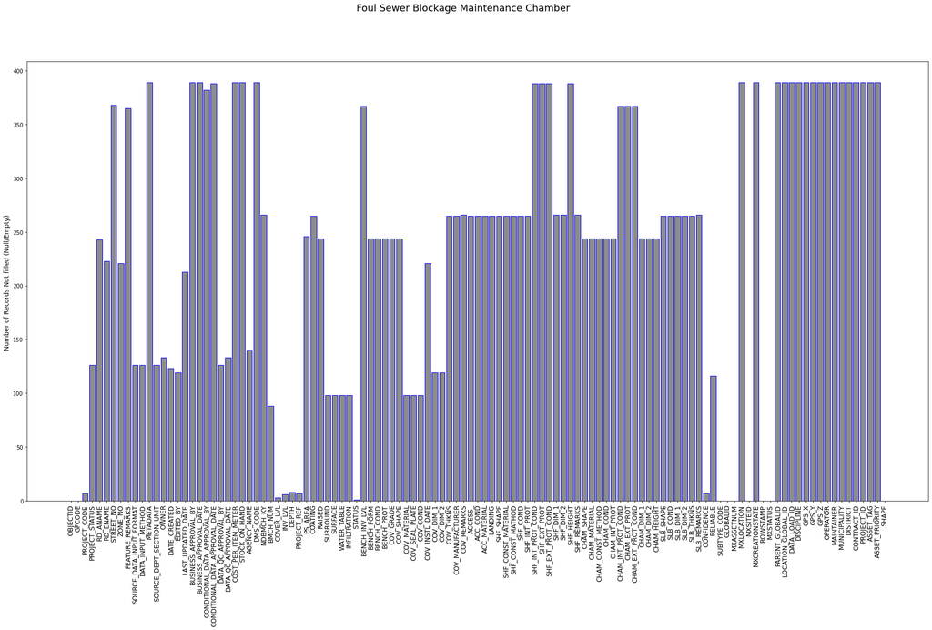

```python
x = FS_Blockage_Maintenance_Chamber.columns
y = FS_Blockage_Maintenance_Chamber.isnull().sum()
plt.figure(figsize=(30,15))
plt.bar(x, y, color= (0.1,0.1,0.1,0.5),  edgecolor='Blue')
plt.suptitle("Foul Sewer Blockage Maintenance Chamber", fontsize=18)
plt.ylabel("Number of Records Not filled (Null/Empty) ", fontsize=12)
plt.xticks(rotation=90, fontsize=12)
plt.show()
```

### 14. Foul Sewer Cover

Foul Sewer Cover feature class has:

```
    •   Attribute Fields (Columns): 77
    •   Total Records (Rows): 3,582
```

```python
FS_Cover = pd.DataFrame.spatial.from_featureclass(r"C:\Users\esd_kgathogo\AppData\Roaming\ESRI\Desktop10.7\ArcCatalog\PWAROADS.sde\SDE.DRG_FOUL_SEWER_NETWORK\SDE.SWNDCOVR")
FS_Cover.head(2)
```

|  | OBJECTID | GFCODE | PROJECT_CODE | PROJECT_STATUS | RD_ANAME | RD_ENAME | STREET_NO | ZONE_NO | SOURCE_DATA_INPUT_FORMAT | DATA_INPUT_METHOD | METADATA | SOURCE_DEPT_SECTION_UNIT | OWNER | DATE_CREATED | EDITED_BY | LAST_UPDATED_DATE | BUSINESS_APPROVAL_BY | BUSINESS_APPROVAL_DATE | CONDITIONAL_DATA_APPROVAL_BY | CONDITIONAL_DATA_APPROVAL_DATE | DATA_QC_APPROVAL_BY | DATA_QC_APPROVAL_DATE | COST_PER_ITEM_METER | STOCK_ON_HAND | AGENCY_NAME | DMS_CODE | NDCOVRL_KY | EASTING | NORTHING | … |
| --- | --- | --- | --- | --- | --- | --- | --- | --- | --- | --- | --- | --- | --- | --- | --- | --- | --- | --- | --- | --- | --- | --- | --- | --- | --- | --- | --- | --- | --- | --- |
| 0 | 324 | SWNDMHCR | AA/DOM/13-14/M/1591-4.07G | As Built | None | None | NaN | NaN | Excel | Automation | None | Drainage O&M | O&M Drainage | 2020-05-14 | BH | NaT | None | None | None | None | BD | 2020-05-21 | None | None | Ashghal | None | None | 186256.416 | 430906.035 | … |
| 1 | 325 | SWNDMHCR | AA/DOM/13-14/M/1591-4.07G | As Built | None | None | NaN | NaN | Excel | Automation | None | Drainage O&M | O&M Drainage | 2020-05-14 | BH | NaT | None | None | None | None | BD | 2020-05-21 | None | None | Ashghal | None | None | 186308.823 | 430906.408 | … |

```python
FS_Cover.shape
```

```
(3582, 77)
```

```python
FS_Cover_null = pd.DataFrame(FS_Cover.isnull().sum())
```

```python
FS_Cover_null
```

|  | 0 |
| --- | --- |
| OBJECTID | 0 |
| GFCODE | 0 |
| PROJECT_CODE | 31 |
| PROJECT_STATUS | 385 |
| RD_ANAME | 3162 |
| ... | ... |
| RELIABLE | 255 |
| CONFIDENCE | 831 |
| TAKAMUL_CATCHMENT | 0 |
| GLOBALID | 0 |
| SHAPE | 0 |

77 rows × 1 columns

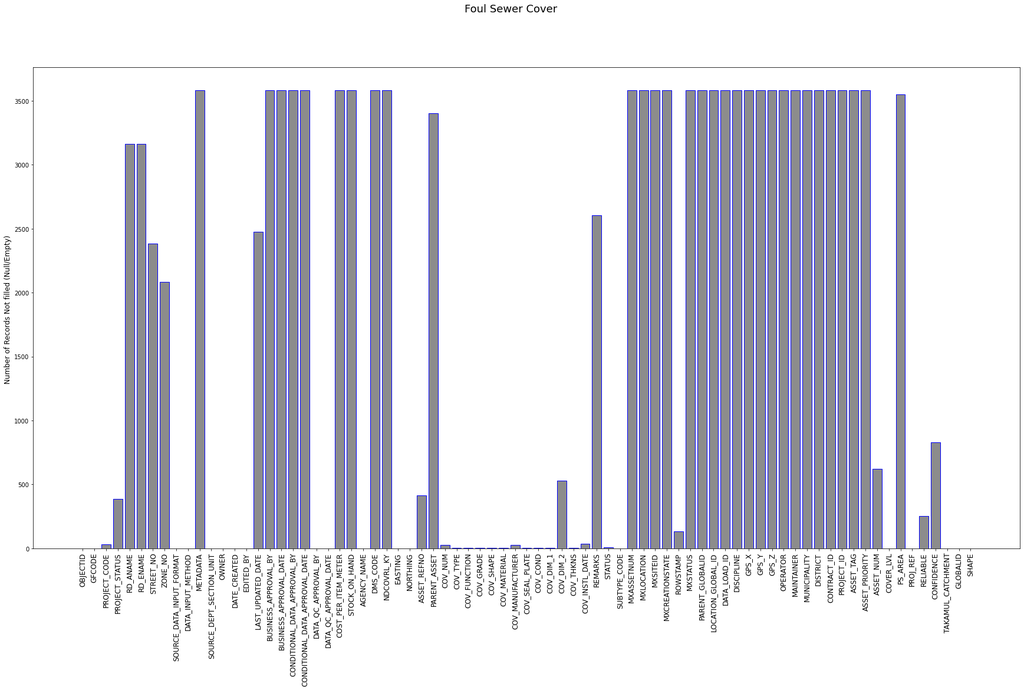

```python
x = FS_Cover.columns
y = FS_Cover.isnull().sum()
plt.figure(figsize=(30,15))
plt.bar(x, y, color= (0.1,0.1,0.1,0.5),  edgecolor='Blue')
plt.suptitle("Foul Sewer Cover", fontsize=18)
plt.ylabel("Number of Records Not filled (Null/Empty) ", fontsize=12)
plt.xticks(rotation=90, fontsize=12)
plt.show()
```

### 15. Foul Sewer Discharge Chamber

Foul Sewer Discharge Chamber feature class has:

```
    •   Attribute Fields (Columns): 111
    •   Total Records (Rows): 200
```

```python
FS_Discharge_Chamber = pd.DataFrame.spatial.from_featureclass(r"C:\Users\esd_kgathogo\AppData\Roaming\ESRI\Desktop10.7\ArcCatalog\PWAROADS.sde\SDE.DRG_FOUL_SEWER_NETWORK\SDE.SWNDDSCH")
FS_Discharge_Chamber.head(2)
```

|  | OBJECTID | GFCODE | PROJECT_CODE | PROJECT_STATUS | RD_ANAME | RD_ENAME | STREET_NO | ZONE_NO | FEATURE_REMARKS | SOURCE_DATA_INPUT_FORMAT | DATA_INPUT_METHOD | METADATA | SOURCE_DEPT_SECTION_UNIT | OWNER | DATE_CREATED | EDITED_BY | LAST_UPDATED_DATE | BUSINESS_APPROVAL_BY | BUSINESS_APPROVAL_DATE | CONDITIONAL_DATA_APPROVAL_BY | CONDITIONAL_DATA_APPROVAL_DATE | DATA_QC_APPROVAL_BY | DATA_QC_APPROVAL_DATE | COST_PER_ITEM_METER | STOCK_ON_HAND | AGENCY_NAME | DMS_CODE | NDDSCH_KY | EASTING | … |
| --- | --- | --- | --- | --- | --- | --- | --- | --- | --- | --- | --- | --- | --- | --- | --- | --- | --- | --- | --- | --- | --- | --- | --- | --- | --- | --- | --- | --- | --- | --- |
| 0 | 12040 | SWNDDSCH | IA 10/11 C 117 G | As Built Yet to be Approved | None | None | NaN | NaN | None | Excel | Automation | None | Drainage O&M | O&M Drainage | 2021-05-27 | VB/ES | 2021-08-09 | None | NaT | None | NaT | ES | 2021-08-09 | NaN | None | Ashghal | None | NaN | 231228.426 | … |
| 1 | 12041 | SWNDDSCH | IA 10/11 C 117 G | As Built Yet to be Approved | None | None | NaN | 66.0 | None | Excel | Automation | None | Drainage O&M | O&M Drainage | 2020-12-20 | VV | 2021-08-09 | None | 2021-08-09 | None | NaT | ES | 2020-12-20 | NaN | None | Ashghal | None | NaN | 231473.679 | … |

2 rows × 111 columns

```python
FS_Discharge_Chamber.shape
```

```
(205, 111)
```

```python
FS_Discharge_Chamber_null = pd.DataFrame(FS_Discharge_Chamber.isnull().sum())
```

```python
FS_Discharge_Chamber_null
```

|  | 0 |
| --- | --- |
| OBJECTID | 0 |
| GFCODE | 0 |
| PROJECT_CODE | 0 |
| PROJECT_STATUS | 154 |
| RD_ANAME | 201 |
| ... | ... |
| CONTRACT_ID | 205 |
| PROJECT_ID | 205 |
| ASSET_TAG | 205 |
| ASSET_PRIORITY | 205 |
| SHAPE | 0 |

111 rows × 1 columns

[figure not shown]

```python
x = FS_Discharge_Chamber.columns
y = FS_Discharge_Chamber.isnull().sum()
plt.figure(figsize=(30,15))
plt.bar(x, y, color= (0.1,0.1,0.1,0.5),  edgecolor='Blue')
plt.suptitle("Foul Sewer Area Engineer Boundary", fontsize=18)
plt.ylabel("Number of Records Not filled (Null/Empty) ", fontsize=12)
plt.xticks(rotation=90, fontsize=12)
plt.show()
```

### 16. Foul Sewer Fittings

Foul Sewer Fittings feature class has:

```
    •   Attribute Fields (Columns): 67
    •   Total Records (Rows): 555
```

```python
FS_Fittings = pd.DataFrame.spatial.from_featureclass(r"C:\Users\esd_kgathogo\AppData\Roaming\ESRI\Desktop10.7\ArcCatalog\PWAROADS.sde\SDE.DRG_FOUL_SEWER_NETWORK\SDE.SWNDFITT")
FS_Fittings.head(2)
```

|  | OBJECTID | GFCODE | PROJECT_CODE | PROJECT_STATUS | RD_ANAME | RD_ENAME | STREET_NO | ZONE_NO | SOURCE_DATA_INPUT_FORMAT | DATA_INPUT_METHOD | METADATA | SOURCE_DEPT_SECTION_UNIT | OWNER | DATE_CREATED | EDITED_BY | LAST_UPDATED_DATE | BUSINESS_APPROVAL_BY | BUSINESS_APPROVAL_DATE | CONDITIONAL_DATA_APPROVAL_BY | CONDITIONAL_DATA_APPROVAL_DATE | DATA_QC_APPROVAL_BY | DATA_QC_APPROVAL_DATE | COST_PER_ITEM_METER | STOCK_ON_HAND | AGENCY_NAME | DMS_CODE | NDFITT_KY | EASTING | NORTHING | … |
| --- | --- | --- | --- | --- | --- | --- | --- | --- | --- | --- | --- | --- | --- | --- | --- | --- | --- | --- | --- | --- | --- | --- | --- | --- | --- | --- | --- | --- | --- | --- |
| 0 | 643 | SWNDFITT | IA 13/14 C 12G | As Built Yet to be Approved | None | None | NaN | NaN | Excel | Automation | None | Drainage O&M | O&M Drainage | 2020-06-02 | IW | NaT | None | None | None | None | BD | 2020-07-21 | None | None | Ashghal | None | None | 228255.6989 | 391528.1491 | … |
| 1 | 644 | SWNDFITT | IA 13/14 C 12G | As Built Yet to be Approved | None | None | NaN | NaN | Excel | Automation | None | Drainage O&M | O&M Drainage | 2020-06-02 | IW | NaT | None | None | None | None | BD | 2020-07-21 | None | None | Ashghal | None | None | 228257.7331 | 391519.9422 | … |

```python
FS_Fittings.shape
```

```
(555, 67)
```

```python
FS_Fittings_null = pd.DataFrame(FS_Fittings.isnull().sum())
```

```python
FS_Fittings_null
```

|  | 0 |
| --- | --- |
| OBJECTID | 0 |
| GFCODE | 0 |
| PROJECT_CODE | 1 |
| PROJECT_STATUS | 1 |
| RD_ANAME | 548 |
| ... | ... |
| RELIABLE | 27 |
| CONFIDENCE | 16 |
| TAKAMUL_CATCHMENT | 143 |
| GLOBALID | 0 |
| SHAPE | 0 |

67 rows × 1 columns

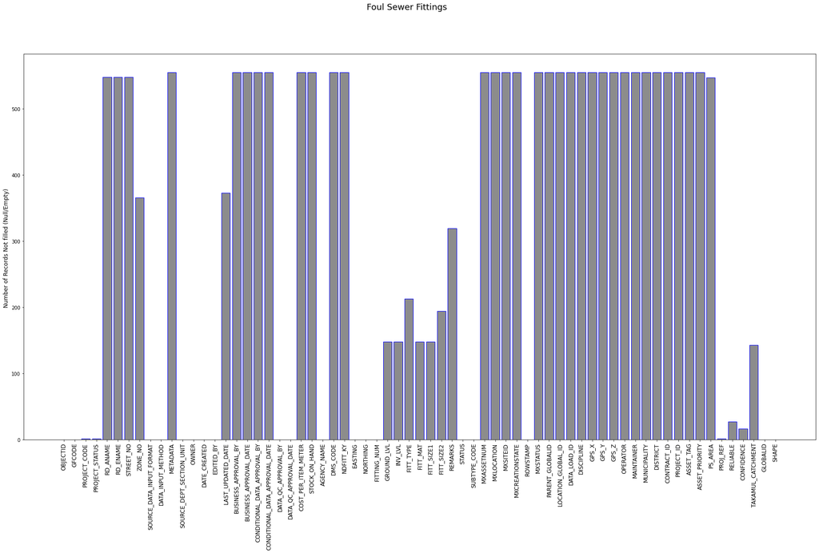

```python
x = FS_Fittings.columns
y = FS_Fittings.isnull().sum()
plt.figure(figsize=(30,15))
plt.bar(x, y, color= (0.1,0.1,0.1,0.5),  edgecolor='Blue')
plt.suptitle("Foul Sewer Fittings", fontsize=18)
plt.ylabel("Number of Records Not filled (Null/Empty) ", fontsize=12)
plt.xticks(rotation=90, fontsize=12)
plt.show()
```

### 17. Foul Sewer House Connection Stub End

[output not shown]

```python
FS_House_Connection_Stub_End = pd.DataFrame.spatial.from_featureclass(r"C:\Users\esd_kgathogo\AppData\Roaming\ESRI\Desktop10.7\ArcCatalog\PWAROADS.sde\SDE.DRG_FOUL_SEWER_NETWORK\SDE.SWNDHCST")
FS_House_Connection_Stub_End.head(2)
```

|  | OBJECTID | GFCODE | PROJECT_CODE | PROJECT_STATUS | RD_ANAME | RD_ENAME | STREET_NO | ZONE_NO | FEATURE_REMARKS | SOURCE_DATA_INPUT_FORMAT | DATA_INPUT_METHOD | METADATA | SOURCE_DEPT_SECTION_UNIT | OWNER | DATE_CREATED | EDITED_BY | LAST_UPDATED_DATE | BUSINESS_APPROVAL_BY | BUSINESS_APPROVAL_DATE | CONDITIONAL_DATA_APPROVAL_BY | CONDITIONAL_DATA_APPROVAL_DATE | DATA_QC_APPROVAL_BY | DATA_QC_APPROVAL_DATE | COST_PER_ITEM_METER | STOCK_ON_HAND | AGENCY_NAME | DMS_CODE | NDHCST_KY | HC_REF_NUM | … |
| --- | --- | --- | --- | --- | --- | --- | --- | --- | --- | --- | --- | --- | --- | --- | --- | --- | --- | --- | --- | --- | --- | --- | --- | --- | --- | --- | --- | --- | --- | --- |
| 0 | 1247813 | SWNDHCST |  | None | None | None | NaN | NaN | None | None | None | None | None | None | NaT | None | NaT | None | NaT | None | NaT | None | NaT | NaN | NaN | Ashghal | None | 64015.0 | 521 | … |
| 1 | 1247468 | SWNDHCST | IA 14/15 C 057 ST | As Built Yet to be Approved | شارع 414 | Street 414 | 414.0 | 91.0 | None | Excel | Automation | None | Drainage O&M | O&M Drainage | 2020-11-01 | VB | 2020-12-09 | None | NaT | None | NaT | ES | 2020-12-09 | NaN | NaN | Ashghal | None | NaN | W9/2/10/4/ST2 | … |

```python
FS_House_Connection_Stub_End.shape
```

```
(38791, 65)
```

```python
SG_Water_Rising_Main_null = pd.DataFrame(FS_House_Connection_Stub_End.isnull().sum())
```

```python
SG_Water_Rising_Main_null
```

|  | 0 |
| --- | --- |
| OBJECTID | 0 |
| GFCODE | 0 |
| PROJECT_CODE | 0 |
| PROJECT_STATUS | 15405 |
| RD_ANAME | 36051 |
| ... | ... |
| CONTRACT_ID | 38755 |
| PROJECT_ID | 38791 |
| ASSET_TAG | 38790 |
| ASSET_PRIORITY | 38791 |
| SHAPE | 1 |

65 rows × 1 columns

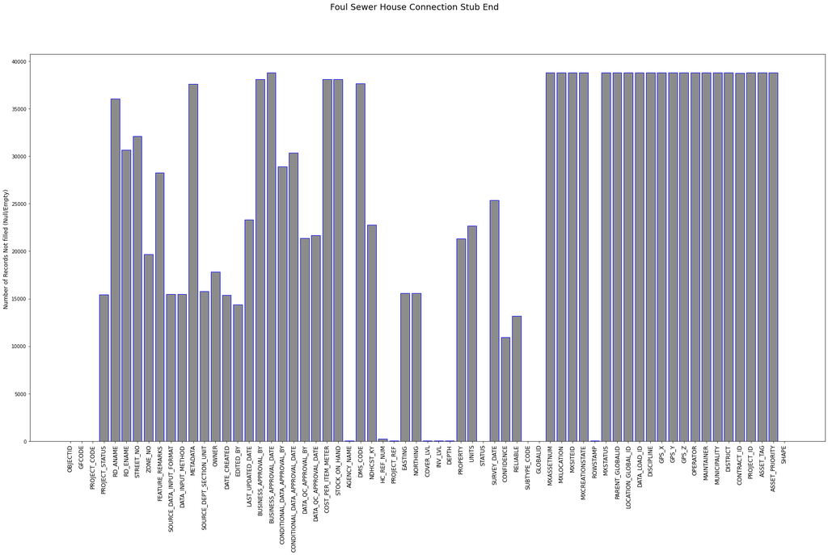

```python
x = FS_House_Connection_Stub_End.columns
y = FS_House_Connection_Stub_End.isnull().sum()
plt.figure(figsize=(30,15))
plt.bar(x, y, color= (0.1,0.1,0.1,0.5),  edgecolor='Blue')
plt.suptitle("Foul Sewer House Connection Stub End", fontsize=18)
plt.ylabel("Number of Records Not filled (Null/Empty) ", fontsize=12)
plt.xticks(rotation=90, fontsize=12)
plt.show()
```

### 18. Foul Sewer Lagoon and Tank

Foul Sewer Lagoon and Tank feature class has:

[output not shown]

```python
FS_Lagoon_Tank = pd.DataFrame.spatial.from_featureclass(r"C:\Users\esd_kgathogo\AppData\Roaming\ESRI\Desktop10.7\ArcCatalog\PWAROADS.sde\SDE.DRG_FOUL_SEWER_NETWORK\SDE.SWNDLGON")
FS_Lagoon_Tank.head(2)
```

|  | OBJECTID | GFCODE | FEATURE_NAME | PROJECT_CODE | PROJECT_STATUS | RD_ANAME | RD_ENAME | STREET_NO | ZONE_NO | FEATURE_REMARKS | SOURCE_DATA_INPUT_FORMAT | DATA_INPUT_METHOD | METADATA | SOURCE_DEPT_SECTION_UNIT | OWNER | DATE_CREATED | EDITED_BY | LAST_UPDATED_DATE | BUSINESS_APPROVAL_BY | BUSINESS_APPROVAL_DATE | CONDITIONAL_DATA_APPROVAL_BY | CONDITIONAL_DATA_APPROVAL_DATE | DATA_QC_APPROVAL_BY | DATA_QC_APPROVAL_DATE | COST_PER_ITEM_METER | STOCK_ON_HAND | AGENCY_NAME | DMS_CODE | TANK_NUM | … |
| --- | --- | --- | --- | --- | --- | --- | --- | --- | --- | --- | --- | --- | --- | --- | --- | --- | --- | --- | --- | --- | --- | --- | --- | --- | --- | --- | --- | --- | --- | --- |
| 0 | 9644 | SWNDHDTK | Grease Trap | IA/10-11/C/13/G | As Built | المتوكل | AL MUTAWAKIL | NaN | NaN | None | Excel | Digitization | None | Drainage O&M | O&M Drainage | 2016-01-24 11:13:26 | Ayman | 2017-04-23 14:01:43 | None | NaT | Ayman | 2016-01-24 11:13:42 | Ayman | 2017-04-23 13:05:01 | None | None | Ashghal | None | Grease Trap | … |
| 1 | 9645 | SWNDHDTK | Wet Well | IA/10-11/C/13/G | As Built | المتوكل | AL MUTAWAKIL | NaN | NaN | None | Excel | Digitization | None | Drainage O&M | O&M Drainage | 2017-04-23 13:04:41 | Ayman | 2017-04-23 13:04:48 | None | NaT | Ayman | 2017-04-23 13:04:54 | Ayman | 2017-04-23 13:05:01 | None | None | Ashghal | None | Wet Well | … |

2 rows × 201 columns

```python
FS_Lagoon_Tank.shape
```

```
(31, 201)
```

```python
FS_Lagoon_Tank_null = pd.DataFrame(FS_Lagoon_Tank.isnull().sum())
```

```python
FS_Lagoon_Tank_null
```

|  | 0 |
| --- | --- |
| OBJECTID | 0 |
| GFCODE | 1 |
| FEATURE_NAME | 13 |
| PROJECT_CODE | 7 |
| PROJECT_STATUS | 9 |
| ... | ... |
| SUBTYPE_CODE | 0 |
| GLOBALID | 0 |
| STATUS | 12 |
| ASSET_TAG | 31 |
| SHAPE | 0 |

201 rows × 1 columns

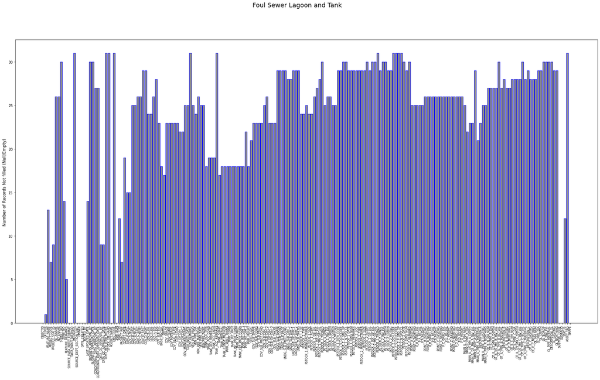

```python
x = FS_Lagoon_Tank.columns
y = FS_Lagoon_Tank.isnull().sum()
plt.figure(figsize=(30,15))
plt.bar(x, y, color= (0.1,0.1,0.1,0.5),  edgecolor='Blue')
plt.suptitle("Foul Sewer Lagoon and Tank", fontsize=18)
plt.ylabel("Number of Records Not filled (Null/Empty) ", fontsize=12)
plt.xticks(rotation=90, fontsize=8)
plt.show()
```

### 19. Foul Sewer Manhole One

Foul Sewer Manhole One feature class has:

[output not shown]

```python
FS_Manhole_One = pd.DataFrame.spatial.from_featureclass(r"C:\Users\esd_kgathogo\AppData\Roaming\ESRI\Desktop10.7\ArcCatalog\PWAROADS.sde\SDE.DRG_FOUL_SEWER_NETWORK\SDE.SWNDMHON")
FS_Manhole_One.head(2)
```

|  | OBJECTID | GFCODE | PROJECT_CODE | PROJECT_STATUS | RD_ANAME | RD_ENAME | STREET_NO | ZONE_NO | FEATURE_REMARKS | SOURCE_DATA_INPUT_FORMAT | DATA_INPUT_METHOD | METADATA | SOURCE_DEPT_SECTION_UNIT | OWNER | DATE_CREATED | EDITED_BY | LAST_UPDATED_DATE | BUSINESS_APPROVAL_BY | BUSINESS_APPROVAL_DATE | CONDITIONAL_DATA_APPROVAL_BY | CONDITIONAL_DATA_APPROVAL_DATE | DATA_QC_APPROVAL_BY | DATA_QC_APPROVAL_DATE | COST_PER_ITEM_METER | STOCK_ON_HAND | AGENCY_NAME | DMS_CODE | HC_NUM | PROJECT_REF | … |
| --- | --- | --- | --- | --- | --- | --- | --- | --- | --- | --- | --- | --- | --- | --- | --- | --- | --- | --- | --- | --- | --- | --- | --- | --- | --- | --- | --- | --- | --- | --- |
| 0 | 3031356 | SWNDMHON | AA-DOM 13/14 M 1591-4.07G | As Built | None | None | NaN | NaN | 9/A7/1/4/IC2/HC1 | Excel | Automation | None | Drainage O&M | O&M Drainage | 2021-01-31 | VV | 2021-06-03 | None | NaT | None | NaT | VV/ES | 2021-01-31 | None | NaN | Ashghal | None | 9/A7/1/4/IC2/HC1 | C2018/42 | … |
| 1 | 3031922 | SWNDMHON |  | None | None | AFEEF | 950.0 | 37.0 |  | None | None | None | None | None | NaT | None | NaT | None | NaT | None | NaT | None | NaT | None | NaN | None | None | 413CN1 | None | … |

```python
FS_Manhole_One.shape
```

```
(79322, 65)
```

```python
FS_Manhole_One_null = pd.DataFrame(FS_Manhole_One.isnull().sum())
```

```python
FS_Manhole_One_null
```

|  | 0 |
| --- | --- |
| OBJECTID | 0 |
| GFCODE | 0 |
| PROJECT_CODE | 4670 |
| PROJECT_STATUS | 50693 |
| RD_ANAME | 76676 |
| ... | ... |
| CONTRACT_ID | 78866 |
| PROJECT_ID | 79091 |
| ASSET_TAG | 79091 |
| ASSET_PRIORITY | 79322 |
| SHAPE | 0 |

65 rows × 1 columns

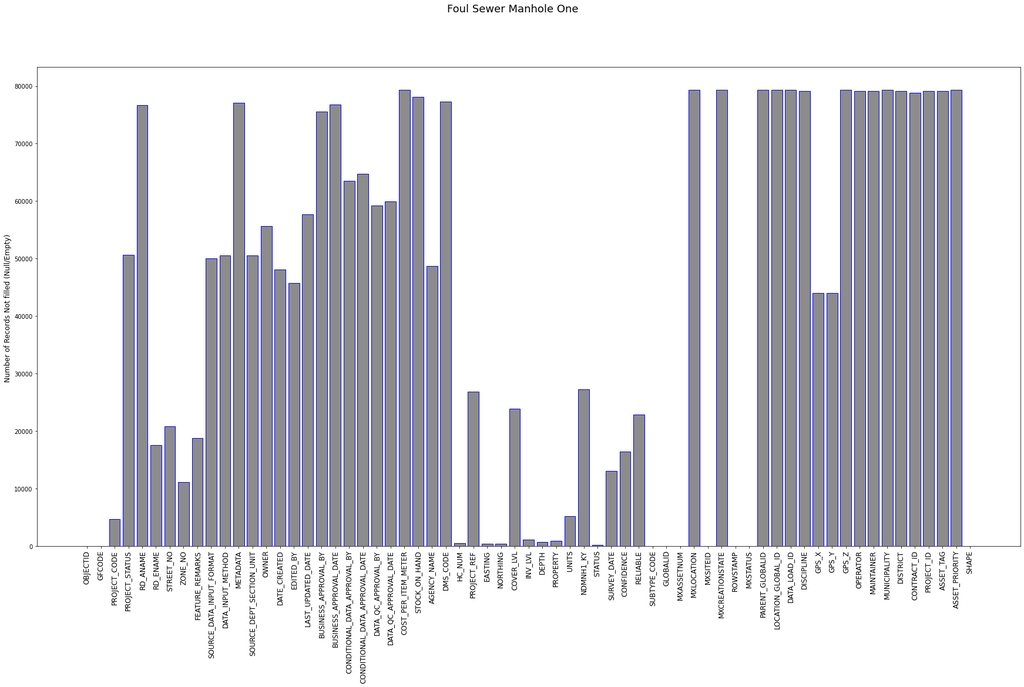

```python
x = FS_Manhole_One.columns
y = FS_Manhole_One.isnull().sum()
plt.figure(figsize=(30,15))
plt.bar(x, y, color= (0.1,0.1,0.1,0.5),  edgecolor='Blue')
plt.suptitle("Foul Sewer Manhole One", fontsize=18)
plt.ylabel("Number of Records Not filled (Null/Empty) ", fontsize=12)
plt.xticks(rotation=90, fontsize=12)
plt.show()
```

### 20. Foul Sewer Manhole

Foul Sewer Manhole feature class has:

[output not shown]

```python
FS_Manhole = pd.DataFrame.spatial.from_featureclass(r"C:\Users\esd_kgathogo\AppData\Roaming\ESRI\Desktop10.7\ArcCatalog\PWAROADS.sde\SDE.DRG_FOUL_SEWER_NETWORK\SDE.SWNDMNHL")
FS_Manhole.head(2)
```

|  | OBJECTID | GFCODE | PROJECT_CODE | PROJECT_STATUS | RD_ANAME | RD_ENAME | STREET_NO | ZONE_NO | FEATURE_REMARKS | SOURCE_DATA_INPUT_FORMAT | DATA_INPUT_METHOD | METADATA | SOURCE_DEPT_SECTION_UNIT | OWNER | DATE_CREATED | EDITED_BY | LAST_UPDATED_DATE | BUSINESS_APPROVAL_BY | BUSINESS_APPROVAL_DATE | CONDITIONAL_DATA_APPROVAL_BY | CONDITIONAL_DATA_APPROVAL_DATE | DATA_QC_APPROVAL_BY | DATA_QC_APPROVAL_DATE | COST_PER_ITEM_METER | STOCK_ON_HAND | AGENCY_NAME | DMS_CODE | NDMNHL_KY | EASTING | … |
| --- | --- | --- | --- | --- | --- | --- | --- | --- | --- | --- | --- | --- | --- | --- | --- | --- | --- | --- | --- | --- | --- | --- | --- | --- | --- | --- | --- | --- | --- | --- |
| 0 | 3214776 | SWNDMNHL | AA DOM 13-14 M 1542-4.07G | As Built | None | None | NaN | NaN | CWR 01 | Excel | Automation | None | Drainage O&M | O&M Drainage | 2017-04-26 07:59:37 | Ayman | 2017-11-05 12:23:46 | None | NaT | Ayman | 2017-05-03 14:17:35 | Ayman | 2017-05-03 14:17:45 | NaN | NaN | Ashghal | None | NaN | 231953.381 | … |
| 1 | 3214358 | SWNDMNHL |  | SURVEY | None |  | NaN | NaN |  | None | None | None | None | None | 1993-06-26 00:00:00 | None | NaT | None | NaT | None | NaT | None | NaT | NaN | NaN | None | None | 3773.0 | 224471.368 | … |

2 rows × 142 columns

```python
FS_Manhole.shape
```

```
(85911, 142)
```

```python
FS_Manhole_null = pd.DataFrame(FS_Manhole.isnull().sum())
```

```python
FS_Manhole_null
```

|  | 0 |
| --- | --- |
| OBJECTID | 0 |
| GFCODE | 0 |
| PROJECT_CODE | 87 |
| PROJECT_STATUS | 962 |
| RD_ANAME | 82716 |
| ... | ... |
| CONTRACT_ID | 85779 |
| PROJECT_ID | 85911 |
| ASSET_TAG | 85911 |
| ASSET_PRIORITY | 85911 |
| SHAPE | 1 |

142 rows × 1 columns

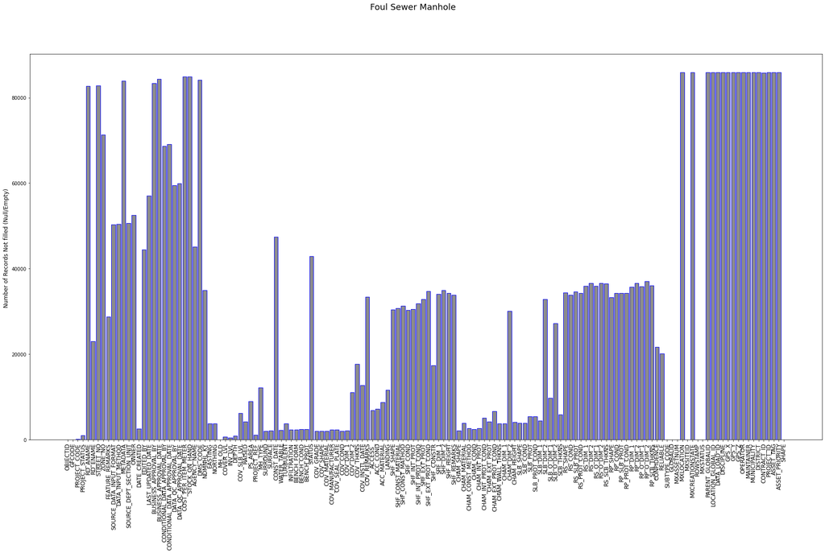

```python
x = FS_Manhole.columns
y = FS_Manhole.isnull().sum()
plt.figure(figsize=(30,15))
plt.bar(x, y, color= (0.1,0.1,0.1,0.5),  edgecolor='Blue')
plt.suptitle("Foul Sewer Manhole", fontsize=18)
plt.ylabel("Number of Records Not filled (Null/Empty) ", fontsize=12)
plt.xticks(rotation=90, fontsize=12)
plt.show()
```

### 21. Foul Sewer Micro Tunnel Manhole

Foul Sewer Micro Tunnel Manhole feature class has:

[output not shown]

```python
FS_MT_Manhole = pd.DataFrame.spatial.from_featureclass(r"C:\Users\esd_kgathogo\AppData\Roaming\ESRI\Desktop10.7\ArcCatalog\PWAROADS.sde\SDE.DRG_FOUL_SEWER_NETWORK\SDE.SWNDMTMH")
FS_MT_Manhole.head(2)
```

|  | OBJECTID | GFCODE | PROJECT_CODE | PROJECT_STATUS | RD_ANAME | RD_ENAME | STREET_NO | ZONE_NO | FEATURE_REMARKS | SOURCE_DATA_INPUT_FORMAT | DATA_INPUT_METHOD | METADATA | SOURCE_DEPT_SECTION_UNIT | OWNER | DATE_CREATED | EDITED_BY | LAST_UPDATED_DATE | BUSINESS_APPROVAL_BY | BUSINESS_APPROVAL_DATE | CONDITIONAL_DATA_APPROVAL_BY | CONDITIONAL_DATA_APPROVAL_DATE | DATA_QC_APPROVAL_BY | DATA_QC_APPROVAL_DATE | COST_PER_ITEM_METER | STOCK_ON_HAND | AGENCY_NAME | DMS_CODE | ARMTMH_KY | SH_MH_NO | … |
| --- | --- | --- | --- | --- | --- | --- | --- | --- | --- | --- | --- | --- | --- | --- | --- | --- | --- | --- | --- | --- | --- | --- | --- | --- | --- | --- | --- | --- | --- | --- |
| 0 | 49211 | SWNDMTMH | IA 10/11 C 07 G | AS BUILT | None | None | NaN | 51.0 | None | XLS | MANUAL | None | O & M | None | 2013-11-26 10:06:45 | ERIC PINTO | NaT | None | None | NISHIN | 2013-09-12 | ERIC | 2014-09-30 13:57:40 | None | None | None | None | NaN | 70/T3/2/59 | … |
| 1 | 49207 | SWNDMTMH | IA 10/11 C 07 G | AS BUILT | None | None | NaN | 51.0 | None | XLS | MANUAL | None | O & M | None | 2013-11-26 10:06:45 | ERIC PINTO | NaT | None | None | NISHIN | 2013-09-12 | ERIC | 2014-09-30 13:57:40 | None | None | None | None | NaN | 70/T3/2/55 | … |

2 rows × 166 columns

```python
FS_MT_Manhole.shape
```

```
(1364, 166)
```

```python
FS_MT_Manhole_null = pd.DataFrame(FS_MT_Manhole.isnull().sum())
```

```python
FS_MT_Manhole_null
```

|  | 0 |
| --- | --- |
| OBJECTID | 0 |
| GFCODE | 0 |
| PROJECT_CODE | 3 |
| PROJECT_STATUS | 4 |
| RD_ANAME | 1215 |
| ... | ... |
| CONTRACT_ID | 1364 |
| PROJECT_ID | 1305 |
| ASSET_TAG | 1305 |
| ASSET_PRIORITY | 1364 |
| SHAPE | 0 |

166 rows × 1 columns

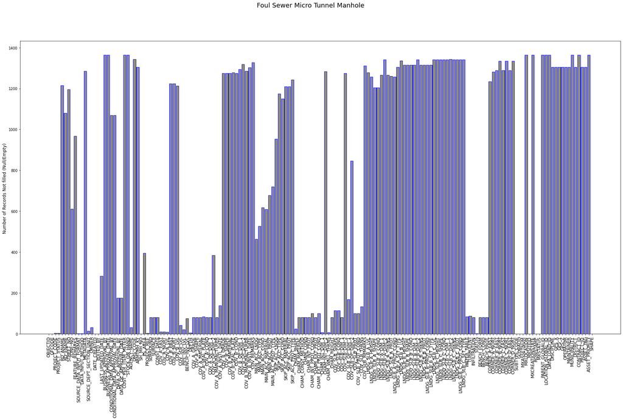

```python
x = FS_MT_Manhole.columns
y = FS_MT_Manhole.isnull().sum()
plt.figure(figsize=(30,15))
plt.bar(x, y, color= (0.1,0.1,0.1,0.5),  edgecolor='Blue')
plt.suptitle("Foul Sewer Micro Tunnel Manhole", fontsize=18)
plt.ylabel("Number of Records Not filled (Null/Empty) ", fontsize=12)
plt.xticks(rotation=90, fontsize=12)
plt.show()
```

### 22. Foul Sewer Odour control unit

Foul Sewer Odour control unit feature class has:

```
    •   Attribute Fields (Columns): 104
    •   Total Records (Rows): 42
```

```python
FS_Odour_contr_unit = pd.DataFrame.spatial.from_featureclass(r"C:\Users\esd_kgathogo\AppData\Roaming\ESRI\Desktop10.7\ArcCatalog\PWAROADS.sde\SDE.DRG_FOUL_SEWER_NETWORK\SDE.SWNDOCU")
FS_Odour_contr_unit.head(2)
```

|  | OBJECTID | GFCODE | PROJECT_CODE | PROJECT_STATUS | RD_ANAME | RD_ENAME | STREET_NO | ZONE_NO | FEATURE_REMARKS | SOURCE_DATA_INPUT_FORMAT | DATA_INPUT_METHOD | METADATA | SOURCE_DEPT_SECTION_UNIT | OWNER | DATE_CREATED | EDITED_BY | LAST_UPDATED_DATE | BUSINESS_APPROVAL_BY | BUSINESS_APPROVAL_DATE | CONDITIONAL_DATA_APPROVAL_BY | CONDITIONAL_DATA_APPROVAL_DATE | DATA_QC_APPROVAL_BY | DATA_QC_APPROVAL_DATE | COST_PER_ITEM_METER | STOCK_ON_HAND | AGENCY_NAME | DMS_CODE | PROJ_REF | STATUS | … |
| --- | --- | --- | --- | --- | --- | --- | --- | --- | --- | --- | --- | --- | --- | --- | --- | --- | --- | --- | --- | --- | --- | --- | --- | --- | --- | --- | --- | --- | --- | --- |
| 0 | 33 | SWNDOCU | None | None | None | None | None | None | Weather Station=WS 05 , Ambient Cabinet=AMC 09... | Excel | Automation | None | Drainage O&M | O&M Drainage | 2020-12-08 | VV | 2020-12-08 | None | None | None | None | VV/ES | 2020-12-08 | None | None | Ashghal | None | None | CN | … |
| 1 | 34 | SWNDOCU | None | None | None | None | None | None | Weather Station =WS 24 , Ambient Bollard=AMB 0... | Excel | Automation | None | Drainage O&M | O&M Drainage | 2020-12-08 | VV | 2020-12-08 | None | None | None | None | VV/ES | 2020-12-08 | None | None | Ashghal | None | None | CN | … |

2 rows × 104 columns

```python
FS_Odour_contr_unit.shape
```

```
(42, 104)
```

```python
FS_Odour_contr_unit_null = pd.DataFrame(FS_Odour_contr_unit.isnull().sum())
```

```python
FS_Odour_contr_unit_null
```

|  | 0 |
| --- | --- |
| OBJECTID | 0 |
| GFCODE | 0 |
| PROJECT_CODE | 42 |
| PROJECT_STATUS | 42 |
| RD_ANAME | 42 |
| ... | ... |
| CONDITIONAL_SURVEY_DATE | 42 |
| PHASE | 42 |
| RISK | 42 |
| TAKAMUL_CATCHMENT | 0 |
| SHAPE | 0 |

104 rows × 1 columns

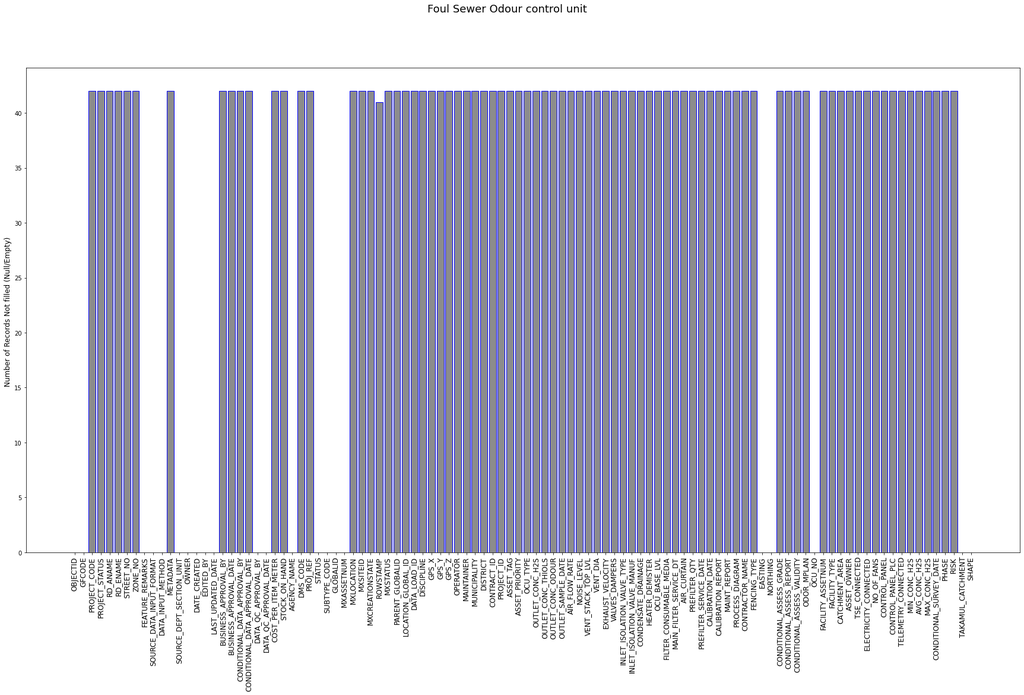

```python
x = FS_Odour_contr_unit.columns
y = FS_Odour_contr_unit.isnull().sum()
plt.figure(figsize=(30,15))
plt.bar(x, y, color= (0.1,0.1,0.1,0.5),  edgecolor='Blue')
plt.suptitle("Foul Sewer Odour control unit", fontsize=18)
plt.ylabel("Number of Records Not filled (Null/Empty) ", fontsize=12)
plt.xticks(rotation=90, fontsize=12)
plt.show()
```

### 23. Foul Sewer Pump Station

```python
FS_Pump_Station = pd.DataFrame.spatial.from_featureclass(r"C:\Users\esd_kgathogo\AppData\Roaming\ESRI\Desktop10.7\ArcCatalog\PWAROADS.sde\SDE.DRG_FOUL_SEWER_NETWORK\SDE.SWNDPSTN")
FS_Pump_Station.head(2)
```

|  | OBJECTID | GFCODE | PROJECT_CODE | PROJECT_STATUS | RD_ENAME | RD_ANAME | STREET_NO | ZONE_NO | FEATURE_REMARKS | SOURCE_DATA_INPUT_FORMAT | DATA_INPUT_METHOD | METADATA | SOURCE_DEPT_SECTION_UNIT | OWNER | DATE_CREATED | EDITED_BY | LAST_UPDATED_DATE | BUSINESS_APPROVAL_BY | BUSINESS_APPROVAL_DATE | CONDITIONAL_DATA_APPROVAL_BY | CONDITIONAL_DATA_APPROVAL_DATE | DATA_QC_APPROVAL_BY | DATA_QC_APPROVAL_DATE | COST_PER_ITEM_METER | STOCK_ON_HAND | AGENCY_NAME | DMS_CODE | PROJECT_REF | PS_NUM | … |
| --- | --- | --- | --- | --- | --- | --- | --- | --- | --- | --- | --- | --- | --- | --- | --- | --- | --- | --- | --- | --- | --- | --- | --- | --- | --- | --- | --- | --- | --- | --- |
| 0 | 14597 | SWNDPSTN | NDIA | As Built Yet to be Approved | None | None | NaN | 49.0 | SLS-SS-009/NDIA PS LIFT STATION | DWG | Manual | None | Drainage O&M | ASHGHAL | 2020-09-13 | ES | 2020-09-13 | None | NaT | None | NaT | ES | 2020-09-13 | None | None | Ashghal | None | 25045 | NDIA-LS8 | … |
| 1 | 14594 | SWNDPSTN | DFC0044 | None | None | None | 294.0 | 48.0 | None | None | None | None | None | ASHGHAL | 1995-11-02 | None | NaT | None | NaT | None | NaT | None | NaT | None | None | None | None | C98 | 17/2 | … |

```python
FS_Pump_Station.shape
```

```
(291, 78)
```

```python
FS_Pump_Station_null = pd.DataFrame(FS_Pump_Station.isnull().sum())
```

```python
FS_Pump_Station_null
```

|  | 0 |
| --- | --- |
| OBJECTID | 0 |
| GFCODE | 0 |
| PROJECT_CODE | 31 |
| PROJECT_STATUS | 198 |
| RD_ENAME | 154 |
| ... | ... |
| CONTRACT_ID | 142 |
| PROJECT_ID | 291 |
| ASSET_TAG | 58 |
| ASSET_PRIORITY | 119 |
| SHAPE | 0 |

78 rows × 1 columns

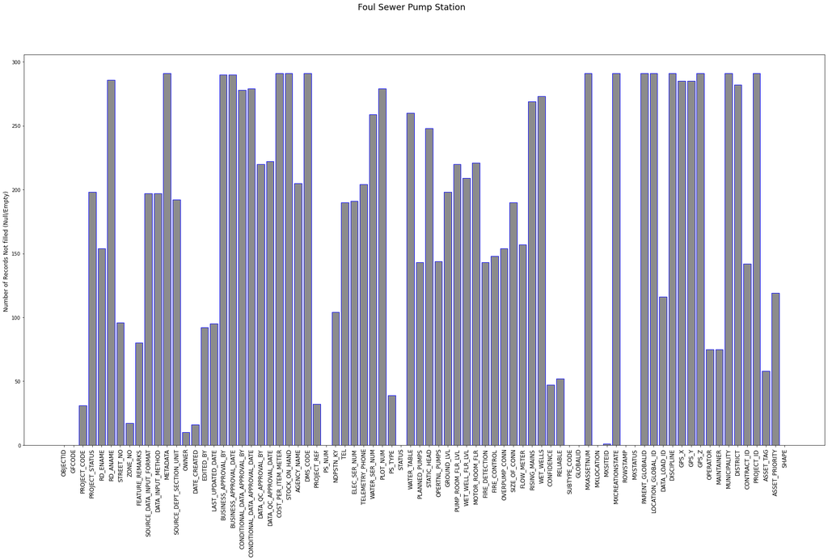

```python
x = FS_Pump_Station.columns
y = FS_Pump_Station.isnull().sum()
plt.figure(figsize=(30,15))
plt.bar(x, y, color= (0.1,0.1,0.1,0.5),  edgecolor='Blue')
plt.suptitle("Foul Sewer Pump Station", fontsize=18)
plt.ylabel("Number of Records Not filled (Null/Empty) ", fontsize=12)
plt.xticks(rotation=90, fontsize=12)
plt.show()
```

### 24. Foul Sewer Septic Tank

Foul Sewer Septic Tank feature class has:

```
    •   Attribute Fields (Columns): 62
    •   Total Records (Rows): 11,128
```

```python
FS_Septic_Tank = pd.DataFrame.spatial.from_featureclass(r"C:\Users\esd_kgathogo\AppData\Roaming\ESRI\Desktop10.7\ArcCatalog\PWAROADS.sde\SDE.DRG_FOUL_SEWER_NETWORK\SDE.SWNDSPTK")
FS_Septic_Tank.head(2)
```

|  | OBJECTID | GFCODE | PROJECT_CODE | PROJECT_STATUS | RD_ANAME | RD_ENAME | STREET_NO | ZONE_NO | FEATURE_REMARKS | SOURCE_DATA_INPUT_FORMAT | DATA_INPUT_METHOD | METADATA | SOURCE_DEPT_SECTION_UNIT | OWNER | DATE_CREATED | EDITED_BY | LAST_UPDATED_DATE | BUSINESS_APPROVAL_BY | BUSINESS_APPROVAL_DATE | CONDITIONAL_DATA_APPROVAL_BY | CONDITIONAL_DATA_APPROVAL_DATE | DATA_QC_APPROVAL_BY | DATA_QC_APPROVAL_DATE | COST_PER_ITEM_METER | STOCK_ON_HAND | AGENCY_NAME | DMS_CODE | NDSTPK_KY | PROJECT_REF | … |
| --- | --- | --- | --- | --- | --- | --- | --- | --- | --- | --- | --- | --- | --- | --- | --- | --- | --- | --- | --- | --- | --- | --- | --- | --- | --- | --- | --- | --- | --- | --- |
| 0 | 516562 | SWNDSPTK | None | None | None | AL QAWAFELL | 950.0 | 38.0 | WORKSHOP | None | None | None | Drainage O&M | O&M Drainage | NaT | Ayman | 2017-02-20 13:26:04 | None | None | None | NaT | None | NaT | None | None | Ashghal | None | 15581 | None | … |
| 1 | 516566 | SWNDSPTK | None | None | None | MURWAB | 807.0 | 53.0 | Edited by Ayman in 20/02/2017 to create MXASSE... | None | None | None | Drainage O&M | O&M Drainage | NaT | Ayman | 2017-02-20 13:25:56 | None | None | None | NaT | None | NaT | None | None | Ashghal | None | 18550 | None | … |

```python
FS_Septic_Tank.shape
```

```
(11128, 62)
```

```python
FS_Septic_Tank_null = pd.DataFrame(FS_Septic_Tank.isnull().sum())
```

```python
FS_Septic_Tank_null
```

|  | 0 |
| --- | --- |
| OBJECTID | 0 |
| GFCODE | 0 |
| PROJECT_CODE | 11128 |
| PROJECT_STATUS | 11128 |
| RD_ANAME | 11128 |
| ... | ... |
| CONTRACT_ID | 11128 |
| PROJECT_ID | 11128 |
| ASSET_TAG | 11128 |
| ASSET_PRIORITY | 11128 |
| SHAPE | 0 |

62 rows × 1 columns

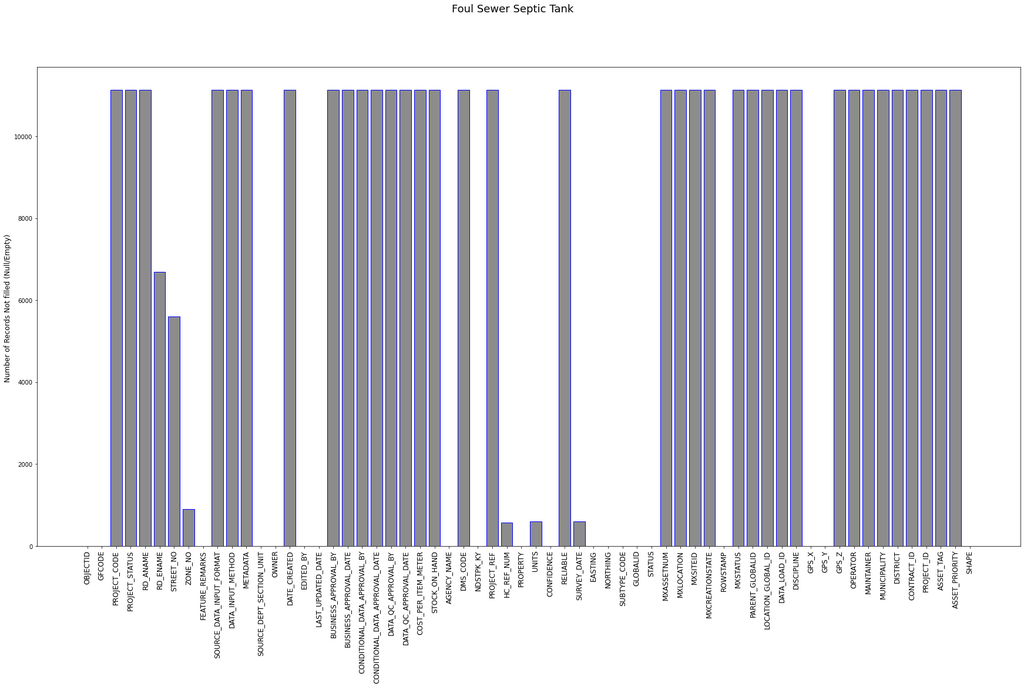

```python
x = FS_Septic_Tank.columns
y = FS_Septic_Tank.isnull().sum()
plt.figure(figsize=(30,15))
plt.bar(x, y, color= (0.1,0.1,0.1,0.5),  edgecolor='Blue')
plt.suptitle("Foul Sewer Septic Tank", fontsize=18)
plt.ylabel("Number of Records Not filled (Null/Empty) ", fontsize=12)
plt.xticks(rotation=90, fontsize=12)
plt.show()
```

### 25. Foul Sewer Stub End (End Cap)

Foul Sewer Stub End (End Cap) feature class has:

[output not shown]

```python
FS_Stub_End = pd.DataFrame.spatial.from_featureclass(r"C:\Users\esd_kgathogo\AppData\Roaming\ESRI\Desktop10.7\ArcCatalog\PWAROADS.sde\SDE.DRG_FOUL_SEWER_NETWORK\SDE.SWNDSTUB")
FS_Stub_End.head(2)
```

|  | OBJECTID | GFCODE | PROJECT_CODE | PROJECT_STATUS | RD_ANAME | RD_ENAME | STREET_NO | ZONE_NO | FEATURE_REMARKS | SOURCE_DATA_INPUT_FORMAT | DATA_INPUT_METHOD | METADATA | SOURCE_DEPT_SECTION_UNIT | OWNER | DATE_CREATED | EDITED_BY | LAST_UPDATED_DATE | BUSINESS_APPROVAL_BY | BUSINESS_APPROVAL_DATE | CONDITIONAL_DATA_APPROVAL_BY | CONDITIONAL_DATA_APPROVAL_DATE | DATA_QC_APPROVAL_BY | DATA_QC_APPROVAL_DATE | COST_PER_ITEM_METER | STOCK_ON_HAND | AGENCY_NAME | DMS_CODE | NDMNHL_KY | PS_AREA | … |
| --- | --- | --- | --- | --- | --- | --- | --- | --- | --- | --- | --- | --- | --- | --- | --- | --- | --- | --- | --- | --- | --- | --- | --- | --- | --- | --- | --- | --- | --- | --- |
| 0 | 23834 | SWNDSTUB | lA-D 13/14 DC 08 G | As Built | None | None | NaN | NaN | None | Excel | Automation | None | Drainage O&M | O&M Drainage | 2020-09-07 | BD | NaT | None | NaT | None | NaT | BD | 2020-09-07 | None | None | Ashghal | None | NaN | None | … |
| 1 | 23831 | SWNDSTUB | IA 13/14 C 39M | As Built | None | None | NaN | NaN | None | Excel | Automation | None | Drainage O&M | O&M Drainage | 2020-04-28 | VV | 2020-09-03 | None | NaT | None | NaT | EA/BD | 2020-10-19 | None | None | Ashghal | None | NaN | PS41 | … |

```python
FS_Stub_End.shape
```

```
(654, 64)
```

```python
FS_Stub_End_null = pd.DataFrame(FS_Stub_End.isnull().sum())
```

```python
FS_Stub_End_null
```

|  | 0 |
| --- | --- |
| OBJECTID | 0 |
| GFCODE | 0 |
| PROJECT_CODE | 0 |
| PROJECT_STATUS | 17 |
| RD_ANAME | 519 |
| ... | ... |
| CONTRACT_ID | 654 |
| PROJECT_ID | 654 |
| ASSET_TAG | 654 |
| ASSET_PRIORITY | 654 |
| SHAPE | 1 |

64 rows × 1 columns

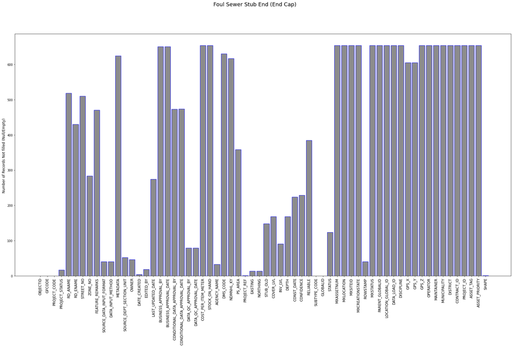

```python
x = FS_Stub_End.columns
y = FS_Stub_End.isnull().sum()
plt.figure(figsize=(30,15))
plt.bar(x, y, color= (0.1,0.1,0.1,0.5),  edgecolor='Blue')
plt.suptitle("Foul Sewer Stub End (End Cap)", fontsize=18)
plt.ylabel("Number of Records Not filled (Null/Empty) ", fontsize=12)
plt.xticks(rotation=90, fontsize=12)
plt.show()
```

### 26. Foul Sewer Valve

Foul Sewer Valve feature class has:

[output not shown]

```python
FS_Valve = pd.DataFrame.spatial.from_featureclass(r"C:\Users\esd_kgathogo\AppData\Roaming\ESRI\Desktop10.7\ArcCatalog\PWAROADS.sde\SDE.DRG_FOUL_SEWER_NETWORK\SDE.SWNDVALV")
FS_Valve.head(2)
```

|  | OBJECTID | GFCODE | PROJECT_CODE | PROJECT_STATUS | RD_ANAME | RD_ENAME | STREET_NO | ZONE_NO | FEATURE_REMARKS | SOURCE_DATA_INPUT_FORMAT | DATA_INPUT_METHOD | METADATA | SOURCE_DEPT_SECTION_UNIT | OWNER | DATE_CREATED | EDITED_BY | LAST_UPDATED_DATE | BUSINESS_APPROVAL_BY | BUSINESS_APPROVAL_DATE | CONDITIONAL_DATA_APPROVAL_BY | CONDITIONAL_DATA_APPROVAL_DATE | DATA_QC_APPROVAL_BY | DATA_QC_APPROVAL_DATE | COST_PER_ITEM_METER | STOCK_ON_HAND | AGENCY_NAME | DMS_CODE | NDVALV_KY | VC_OLD | … |
| --- | --- | --- | --- | --- | --- | --- | --- | --- | --- | --- | --- | --- | --- | --- | --- | --- | --- | --- | --- | --- | --- | --- | --- | --- | --- | --- | --- | --- | --- | --- |
| 0 | 61175 | SWNDVALV | 682/3 | As Built | None | None | NaN | NaN | Ref Mechanism Drawing No 7105AF Rev Z | DWG | Manual | None | Drainage O&M | O&M Drainage | NaT | VB/ES | 2019-03-13 | None | NaT | None | NaT | VB/ES | 2019-09-16 09:44:29.000001 | None | None | Ashghal | None | NaN | D/70/8/AV/S3 | … |
| 1 | 61177 | SWNDVALV | 682/3 | As Built | None | None | NaN | NaN | Ref Mechanism Drawing No 7105AG Rev Z | DWG | Manual | None | Drainage O&M | O&M Drainage | NaT | VB/ES | 2019-03-13 | None | NaT | None | NaT | VB/ES | 2019-09-16 09:44:29.000001 | None | None | Ashghal | None | NaN | D/70/9/AV/2 | … |

```python
FS_Valve.shape
```

```
(1633, 71)
```

```python
FS_Valve_null = pd.DataFrame(FS_Valve.isnull().sum())
```

```python
FS_Valve_null
```

|  | 0 |
| --- | --- |
| OBJECTID | 0 |
| GFCODE | 0 |
| PROJECT_CODE | 532 |
| PROJECT_STATUS | 553 |
| RD_ANAME | 1444 |
| ... | ... |
| CONTRACT_ID | 1633 |
| PROJECT_ID | 1633 |
| ASSET_TAG | 1632 |
| ASSET_PRIORITY | 1624 |
| SHAPE | 0 |

71 rows × 1 columns

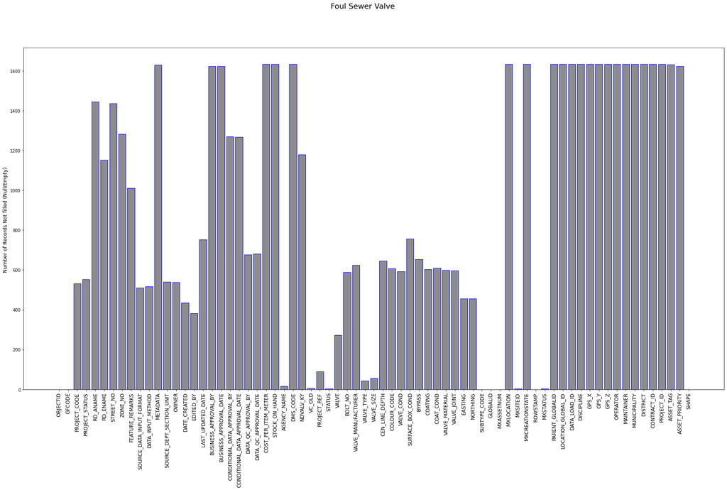

```python
x = FS_Valve.columns
y = FS_Valve.isnull().sum()
plt.figure(figsize=(30,15))
plt.bar(x, y, color= (0.1,0.1,0.1,0.5),  edgecolor='Blue')
plt.suptitle("Foul Sewer Valve", fontsize=18)
plt.ylabel("Number of Records Not filled (Null/Empty) ", fontsize=12)
plt.xticks(rotation=90, fontsize=12)
plt.show()
```

Foul Sewer Valve feature class has:

[output not shown]

```python
FS_Valve_Chamber = pd.DataFrame.spatial.from_featureclass(r"C:\Users\esd_kgathogo\AppData\Roaming\ESRI\Desktop10.7\ArcCatalog\PWAROADS.sde\SDE.DRG_FOUL_SEWER_NETWORK\SDE.SWNDVALV")
FS_Valve_Chamber.head(2)
```

|  | OBJECTID | GFCODE | PROJECT_CODE | PROJECT_STATUS | RD_ANAME | RD_ENAME | STREET_NO | ZONE_NO | FEATURE_REMARKS | SOURCE_DATA_INPUT_FORMAT | DATA_INPUT_METHOD | METADATA | SOURCE_DEPT_SECTION_UNIT | OWNER | DATE_CREATED | EDITED_BY | LAST_UPDATED_DATE | BUSINESS_APPROVAL_BY | BUSINESS_APPROVAL_DATE | CONDITIONAL_DATA_APPROVAL_BY | CONDITIONAL_DATA_APPROVAL_DATE | DATA_QC_APPROVAL_BY | DATA_QC_APPROVAL_DATE | COST_PER_ITEM_METER | STOCK_ON_HAND | AGENCY_NAME | DMS_CODE | NDVALV_KY | VC_OLD | … |
| --- | --- | --- | --- | --- | --- | --- | --- | --- | --- | --- | --- | --- | --- | --- | --- | --- | --- | --- | --- | --- | --- | --- | --- | --- | --- | --- | --- | --- | --- | --- |
| 0 | 61175 | SWNDVALV | 682/3 | As Built | None | None | NaN | NaN | Ref Mechanism Drawing No 7105AF Rev Z | DWG | Manual | None | Drainage O&M | O&M Drainage | NaT | VB/ES | 2019-03-13 | None | NaT | None | NaT | VB/ES | 2019-09-16 09:44:29.000001 | None | None | Ashghal | None | NaN | D/70/8/AV/S3 | … |
| 1 | 61177 | SWNDVALV | 682/3 | As Built | None | None | NaN | NaN | Ref Mechanism Drawing No 7105AG Rev Z | DWG | Manual | None | Drainage O&M | O&M Drainage | NaT | VB/ES | 2019-03-13 | None | NaT | None | NaT | VB/ES | 2019-09-16 09:44:29.000001 | None | None | Ashghal | None | NaN | D/70/9/AV/2 | … |

```python
FS_Valve_Chamber.shape
```

```
(1633, 71)
```

```python
FS_Valve_Chamber_null = pd.DataFrame(FS_Valve_Chamber.isnull().sum())
```

```python
FS_Valve_Chamber_null
```

|  | 0 |
| --- | --- |
| OBJECTID | 0 |
| GFCODE | 0 |
| PROJECT_CODE | 532 |
| PROJECT_STATUS | 553 |
| RD_ANAME | 1444 |
| ... | ... |
| CONTRACT_ID | 1633 |
| PROJECT_ID | 1633 |
| ASSET_TAG | 1632 |
| ASSET_PRIORITY | 1624 |
| SHAPE | 0 |

71 rows × 1 columns

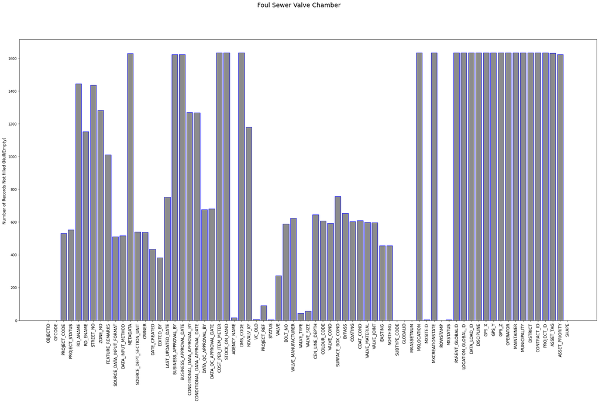

```python
x = FS_Valve_Chamber.columns
y = FS_Valve_Chamber.isnull().sum()
plt.figure(figsize=(30,15))
plt.bar(x, y, color= (0.1,0.1,0.1,0.5),  edgecolor='Blue')
plt.suptitle("Foul Sewer Valve Chamber", fontsize=18)
plt.ylabel("Number of Records Not filled (Null/Empty) ", fontsize=12)
plt.xticks(rotation=90, fontsize=12)
plt.show()
```